# 第6章 金融量化分析常用工具模块(2)

```python
"""
【示例1】talib.CDLDOJI指标：十字星判断。

"""
import pandas as pd
import talib as tb

# 定义函数：确定数组内部含有特定值的个数与位置
def get_id(arr, value):
    indices = []
    for i in range(len(arr)):
        if arr[i] == value:
            indices.append(i)
    print("列表中存在{}个1，它们的位置分别为：{}".format(len(indices), indices))


df = pd.read_csv('d:/600000.csv')    # 修改文件路径
df = df.tail(30)
"""
talib.CDLDOJI 的语法和参数如下：
talib.CDLDOJI(open, high, low, close)
参数：

open：表示开盘价的数组。
high：表示最高价的数组。
low：表示最低价的数组。
close：表示收盘价的数组。
"""
close = df.close.values
open = df.open.values
high = df.high.values
low = df.low.values

cdldoji = tb.CDLDOJI(open,high,low,close)

# 调用get_id函数，确定数组中含有100的个数与位置
print('talib.CDLDOJI函数返回结果：\n',cdldoji)
get_id(cdldoji,100)
```

```
talib.CDLDOJI函数返回结果：
 [  0   0   0   0   0   0   0   0   0   0   0   0   0   0   0   0 100 100
   0   0   0 100   0   0   0   0   0   0   0   0]
列表中存在3个1，它们的位置分别为：[16, 17, 21]
```

```python
"""
【示例2】talib.MA指标：均线指标。
"""
import pandas as pd
import talib as tb

# 定义函数：确定数组内部含有特定值的个数与位置
def get_id(arr, value):
    indices = []
    for i in range(len(arr)):
        if arr[i] == value:
            indices.append(i)
    print("列表中存在{}个1，它们的位置分别为：{}".format(len(indices), indices))


df = pd.read_csv('d:/OneDrive/Python金融量化分析数据文件/600000.csv')    # 修改文件路径
df = df.tail(30)

df['MA2'] = tb.MA(df['close'], timeperiod=2, matype=0)
print(df.head(2))
```

```
    trade_date  open  close  high   low    code  volume   MA2
284   2023/3/9  7.31   7.27  7.34  7.25  600000  265399   NaN
285  2023/3/10  7.24   7.15  7.26  7.15  600000  203773  7.21
```

```python
"""
【示例3】talib.BBANDS指标：布林线指标。
"""
import pandas as pd
import talib as tb

# 定义函数：确定数组内部含有特定值的个数与位置
def get_id(arr, value):
    indices = []
    for i in range(len(arr)):
        if arr[i] == value:
            indices.append(i)
    print("列表中存在{}个1，它们的位置分别为：{}".format(len(indices), indices))


df = pd.read_csv('d:/OneDrive/Python金融量化分析数据文件/600000.csv')    # 修改文件路径
df = df.tail(30)
"""
talib.CDLDOJI 的语法和参数如下：
talib.CDLDOJI(open, high, low, close)
参数：

open：表示开盘价的数组。
high：表示最高价的数组。
low：表示最低价的数组。
close：表示收盘价的数组。
"""
close = df.close.values

upper, middle, lower = tb.BBANDS(close,5, matype=tb.MA_Type.EMA)
#或：
upper, middle, lower = tb.BBANDS(close,5, matype=1)
```

```python
"""
【示例4】empyrical.stats.simple_returns计算简单收益率。
"""
# 引入模块
import empyrical as ep
import pandas as pd
import numpy as np
# 读入数据文件，进行数据清洗
#df = pd.read_csv('d:/金融量化分析书稿数据/sh603110.csv',
#                 encoding='utf-8-sig',usecols=['日期','收盘价'])
df = pd.read_csv('e:/Python金融量化分析数据文件/部分股票数据/sh603110.csv',
                 encoding='utf-8-sig',usecols=['日期','收盘价'])
# 将df变量中0数据替换为空值np.nan
df.replace(0,np.nan,inplace=True)
# 将df变量中空值np.nan替换为前一行值
df.ffill(inplace=True)
# 将df变量中“日期”列数据设为索引列
df.set_index('日期',drop=True,inplace=True)
# 计算简单收益率
returns = ep.stats.simple_returns(df['收盘价'])
# 也可写为“returns = ep. simple_returns(df['收盘价'])”
print("简单收益率returns类型：\n",type(returns))
print('--------------------------------------------')
print(returns)
```

```
简单收益率returns类型：
 <class 'pandas.core.series.Series'>
--------------------------------------------
日期
2017-10-16    0.100106
2017-10-17    0.100194
2017-10-18    0.099868
2017-10-19    0.100000
2017-10-20    0.100000
                ...
2022-12-01    0.035569
2022-12-02   -0.008164
2022-12-05    0.002838
2022-12-06    0.009057
2022-12-07    0.003366
Name: 收盘价, Length: 1253, dtype: float64
```

```python
"""
【示例5】empyrical.stats.cum_returns计算累积收益率。
"""
cum_returns = ep.stats.cum_returns(returns)
print(cum_returns)
```

```
日期
2017-10-16    0.100106
2017-10-17    0.210330
2017-10-18    0.331203
2017-10-19    0.464324
2017-10-20    0.610756
                ...
2022-12-01    0.891374
2022-12-02    0.875932
2022-12-05    0.881257
2022-12-06    0.898296
2022-12-07    0.904686
Length: 1253, dtype: float64
```

```python
"""
【示例6】empyrical.stats.cum_returns_final计算累积收益率终值。
"""
cum_returns_final = ep.stats.cum_returns_final(returns)
print(cum_returns_final)
```

```
0.9046858359957362
```

```python
"""
【示例7】empyrical.stats. max_drawdown计算最大回撤率。
"""
max_drawdown = ep.stats.max_drawdown(returns)
print(max_drawdown)
```

```
-0.7514278619319594
```

```python
"""
【示例8】empyrical.stats. annual_return年化复合收益率。
"""
annual_return = ep.stats.annual_return(returns, period='daily')
print(annual_return)
```

```
0.13835395886222113
```

```python
"""
【示例9】empyrical.stats. annual_volatility 年收益率波动率。
"""
annual_volatility = ep.stats.annual_volatility(returns)
print(annual_volatility)
```

```
0.5351576219058175
```

```python
"""
【示例10】empyrical.stats.calmar_ratio 计算卡玛比率。
"""
calmar_ratio = ep.stats.calmar_ratio(returns)
print(calmar_ratio)
```

```
0.1841214118764588
```

```python
"""
【示例11】empyrical.stats.sharpe_ratio 计算夏普比率。
"""
sharp_ratio = ep.stats.sharpe_ratio(returns)
print(sharp_ratio)
```

```
0.5131607025844898
```

```python
"""
【示例12】empyrical.stats.sortino_ratio 索提诺。
"""
sortino_ratio = ep.stats.sortino_ratio(returns)
print(sortino_ratio)
```

```
0.7515474340294174
```

```python
"""
【示例13】empyrical. stats.alpha计算α值。
"""
# 读取数据
df_data = pd.read_csv('e:/Python金融量化分析数据文件/var_test.csv',encoding='utf-8-sig', usecols=['603110','603501'])

# 数据清洗：用np.nan空值替代0
df_data = df_data.replace(0,np.nan)
# 数据清洗：使用前一个值替代空值
df_data = df_data.ffill()

# 计算目标股票简单收益率
returns_603110 = ep.stats.simple_returns(df_data['603110'])
# 计算benchmark基准股票的简单收益率
benchmark = ep.stats.simple_returns(df_data['603501'])
# 计算目标股票alpha值
alpha = ep.stats.alpha(returns=returns_603110, factor_returns=benchmark, risk_free=0.0001)
print(alpha)
```

```
0.2048824721938547
```

```python
"""
【示例14】empyrical. stats.beta计算β值。
"""
beta = ep.stats.beta(returns=returns_603110, factor_returns=benchmark)
print(beta)
```

```
0.1891363185310878
```

```python
"""
【示例15】empyrical. stats. stability_of_timeseries计算稳定性。
"""
stability_of_timeseries = ep.stats.stability_of_timeseries(returns)
print(stability_of_timeseries)
```

```
0.39968750701912026
```

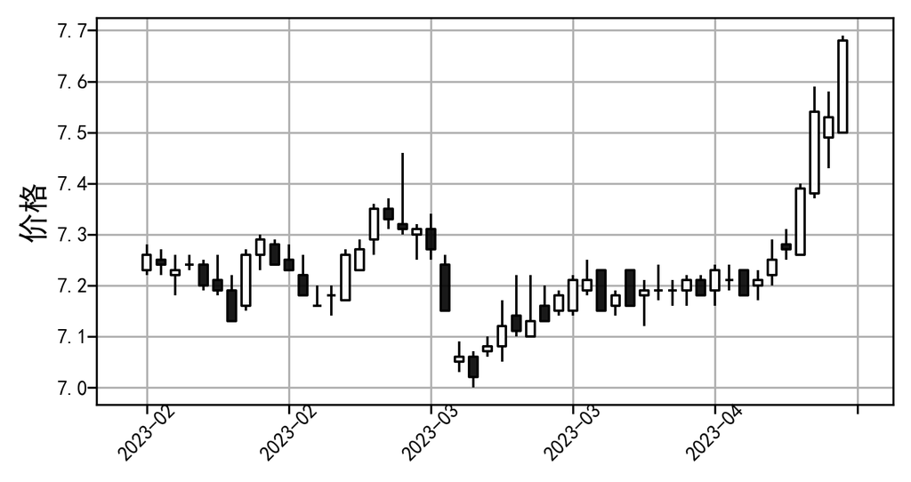

```python
"""
【示例16】mplfinance绘制最基本的K线图。
"""
import pandas as pd
import mplfinance as mpf
import matplotlib.pyplot as plt


# 读取数据为 Pandas DataFrame 格式
df_data = pd.read_csv('e:/Python金融量化分析数据文件/600000.csv'
                      # 将trade_date设为日期类型
                      ,parse_dates=['trade_date'],
                      # 将trade_date设为索引
                      index_col='trade_date')
# 为了显示清晰，只选取最后50个数据
df_data = df_data.iloc[-50:]
# 设置自定义画图风格
style = mpf.make_mpf_style(
    rc={# 设置中文显示为简体黑体
        'font.family': 'SimHei',
        # 设置负号正常显示
        'axes.unicode_minus': 'False',
        # 设置清晰度
       'figure.dpi':300})
# 使用 mplfinance 绘制 K 线图
fig, ax = mpf.plot(df_data,
                   # 图形类型是蜡烛图
                   type='candle',
                   # 日期显示方式如2022-08形式
                   datetime_format='%Y-%m',
                   # 返回值为Figure对象和子图列表对象，否则只返回单一Axis对象
                   returnfig=True,
                   # 设置主图大小
                   figsize=(6, 3),
                   # 风格选用自定义的style
                   style=style,)

# 调整 x 轴标签位置，靠x轴
# ax[0].tick_params(axis='x', pad=-5)

# 设置第一个子图的坐标轴属性
ax[0].tick_params(axis='x',           # 说明设的坐标轴为x轴
                  labelrotation=45,   # 坐标标签倾斜45°
                  labelsize=8,        # 设置坐标标签字体大小
                  pad=-5)             # 设置靠近坐标的距离，负值表示与坐标轴贴近
ax[0].tick_params(axis='y', labelsize=8, pad=-0)
# 手动添加网格线
ax[0].grid()
# 设置轴标签
ax[0].set_ylabel('价格', fontsize=12)
plt.show()
```

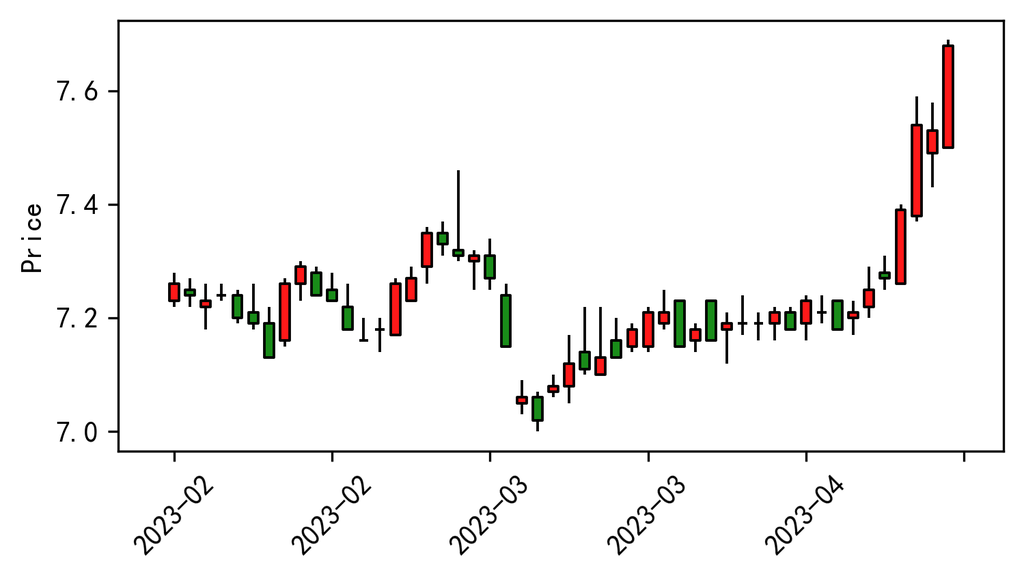

```python
"""
【示例17】mplfinance绘制定义模式的K线图。
"""
# 设置mpf库MarketColors对象，包括K线颜色信息
my_color = mpf.make_marketcolors(
    up='red',           # 表示上涨K线的颜色
    down='green',       # 表示下跌K线的颜色
    edge='black',       # 表示K线的边缘颜色
    wick='black',       # 表示K线上下影线的颜色
    volume='inherit')   # 表示成交量条的颜色

# 将MarketColors对象设置为mpf.make_mpf_style参数
style = mpf.make_mpf_style(
    marketcolors=my_color,          # 设置MarketClors参数
    rc={# 设置中文显示为简体黑体
        'font.family': 'SimHei',
        # 设置负号正常显示
        'axes.unicode_minus': 'False',
        # 设置清晰度
       'figure.dpi':300})
fig, ax = mpf.plot(df_data,
                   type='candle',
                   datetime_format='%Y-%m',
                   returnfig=True,
                   figsize=(6, 3),
                   style=style,)
```

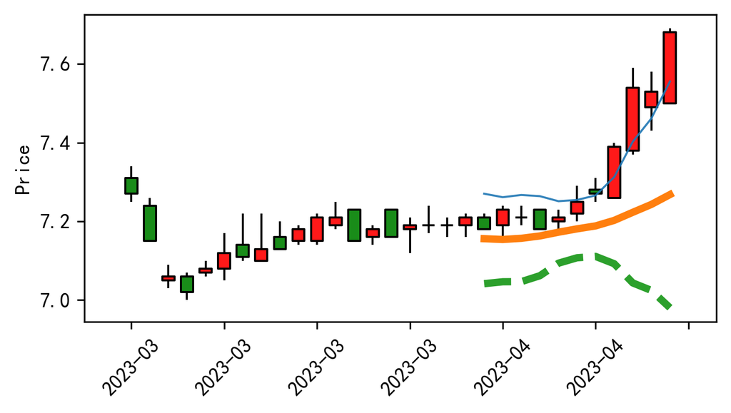

```python
import pandas as pd
import talib as tb
from talib import BBANDS
import mplfinance as mpf

# 定义函数：确定数组内部含有特定值的个数与位置
def get_id(arr, value):
    indices = []
    for i in range(len(arr)):
        if arr[i] == value:
            indices.append(i)
    print("列表中存在{}个1，它们的位置分别为：{}".format(len(indices), indices))


df = pd.read_csv('E:/OneDrive - vfd/SCNU/Python金融量化分析/Python金融量化分析数据文件/600000.csv')    # 修改文件路径
df = df.tail(30)

# 将日期列转换为 Datetime 类型
df['trade_date'] = pd.to_datetime(df['trade_date'], errors='coerce')  # 请根据实际列名修改
df.set_index('trade_date', inplace=True)  # 设置日期列为索引

# 计算布林带指标
close = df.close.values
open = df.open.values
high = df.high.values
low = df.low.values

cdldoji = tb.CDLDOJI(open,high,low,close)

up, mid, low = BBANDS(df['close'],
                      timeperiod=20,
                      nbdevup=2,
                      nbdevdn=2,
                      matype=0)

upline = mpf.make_addplot(up,         # 设置数据列
                          width=1,        # 设置曲线粗细
                          type='line',   # 设置线的类型
                          panel=0,        # 设置显示的子图编号
                          alpha=0.9)      # 设置透明度，0代表全透明

midline = mpf.make_addplot(mid, linestyle='-')
lowline = mpf.make_addplot(low, linestyle='--')

# 将MarketColors对象设置为mpf.make_mpf_style参数
my_color = mpf.make_marketcolors(
    up='red',           # 表示上涨K线的颜色
    down='green',       # 表示下跌K线的颜色
    edge='black',       # 表示K线的边缘颜色
    wick='black',       # 表示K线上下影线的颜色
    volume='inherit')   # 表示成交量条的颜色

style = mpf.make_mpf_style(
    marketcolors=my_color,          # 设置MarketClors参数
    rc={# 设置中文显示为简体黑体
        'font.family': 'SimHei',
        # 设置负号正常显示
        'axes.unicode_minus': 'False',
        # 设置清晰度
       'figure.dpi':300})

# 使用mplfinance绘图
fig, ax = mpf.plot(df,
                   type='candle',
                   datetime_format='%Y-%m',
                   returnfig=True,
                   figsize=(6, 3),
                   style=style,
                   addplot=[upline, midline, lowline])
```

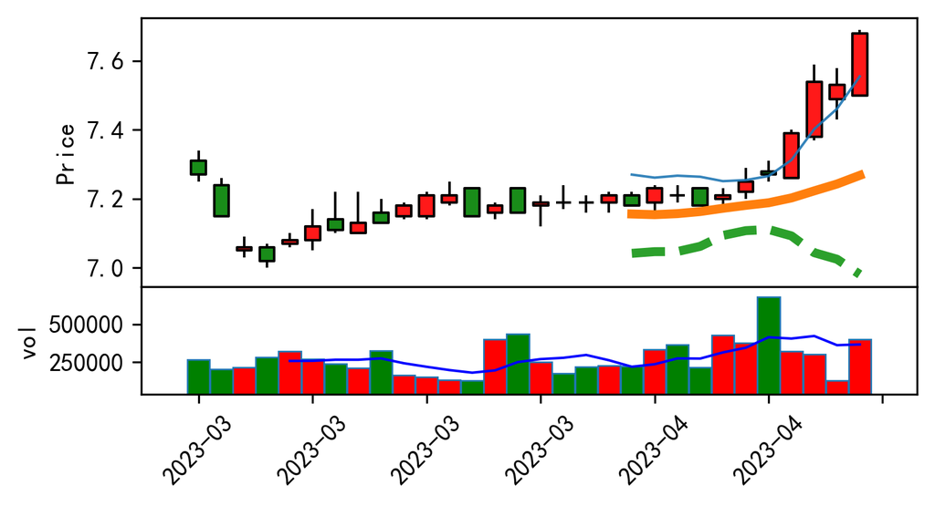

```python
"""
【示例19】绘制含成交量5日均线指标的K线图。
"""
# 成交量5日均线添加至成交量子面板
df['vol_ma5'] = df['volume'].rolling(window=5).mean()
vol_ma5 = mpf.make_addplot(df['vol_ma5'],
                           type='line',
                           color='blue',
                           panel=1,
                           width=1,
                           ylabel='成交量')
fig, ax = mpf.plot(df,
                   type='candle',
                   datetime_format='%Y-%m',
                   returnfig=True,
                   figsize=(6, 3),
                   style=style,
                   addplot=[upline,midline,lowline,vol_ma5],
                   volume=True,
                   ylabel_lower='vol',    # 设置成交量图的y轴标签
                   main_panel=0,          # 设置主图编号为0
                   volume_panel=1,)       # 设置成交量图编号为1
fig.show()
```

### 成交量（Volume）

成交量是股票市场分析中一个非常重要的指标，是市场情绪和趋势强度的重要反映，理解和应用成交量信号有助于分析市场的买卖力量。它表示在一定时间内某一资产交易的总量。成交量信号通过分析成交量的变化，可以帮助投资者确认趋势的强度、预测价格的变动以及识别潜在的反转信号。但是不能单独使用，需要配合其他指标。

以下是几种常见的成交量信号：

#### 1. **成交量与价格的配合**

成交量的变化与价格变动的配合是最常用的成交量信号之一。成交量的信号通常与价格的趋势共同作用，形成以下几种情况：

- **上涨时成交量增加**：当市场价格上涨时，如果成交量随之增加，表示**买盘强劲**，价格上涨的趋势可能会持续。这是一个**确认信号**，表明市场趋势健康。
- **上涨时成交量减少**：如果价格上涨，但成交量却减少，这可能表示**买盘力量不足**，价格上涨的趋势可能会遭遇阻力，可能是一个**警告信号**，暗示价格上涨可能无法持续。
- **下跌时成交量增加**：当市场价格下跌时，成交量增加表明卖盘压力增加，市场情绪偏空，价格下跌的趋势可能会延续。这是一个**确认信号**，表明市场趋势较强。
- **下跌时成交量减少**：如果价格下跌，但成交量减少，可能表示卖盘力量不足，价格下跌趋势可能会放缓。这可能是一个**反转信号**，暗示卖盘动力减弱，市场可能会反弹。

#### 2. **成交量突破**

- **突破交易区间**：当价格突破一个长期的价格区间时，如果伴随着成交量的放大，表示突破是有效的，趋势可能会持续。这种情况通常被称为“**量能突破**”。
- **价格突破无量**：如果价格突破重要的支撑位或阻力位，但成交量没有显著增加，这通常意味着突破可能不具备持续性，市场可能会出现反转或回撤。

#### 3. **量价背离**

量价背离指的是成交量与价格趋势之间的矛盾。常见的量价背离类型包括：

- **价格创新高，成交量不再创新高**：当价格创出新高时，如果成交量未能跟随创出新高，说明市场的买盘力量逐渐减弱，可能是价格即将反转的信号。
- **价格创新低，成交量不再创新低**：当价格创出新低时，如果成交量未能继续放大，说明市场的卖盘压力开始减弱，可能会有反弹。

#### 4. **成交量峰值（Volume Spike）**

成交量峰值指的是某个时间段内成交量大幅上升，通常伴随着价格剧烈波动。这种情况下，成交量的突然增加可能是市场情绪发生了剧烈变化的信号，通常可以分为：

- **买盘放量**：如果成交量大幅上升并且价格上涨，说明市场的买盘活跃，可能是一个看涨信号。
- **卖盘放量**：如果成交量大幅上升并且价格下跌，说明市场的卖盘压力增加，可能是一个看跌信号。

#### 5. **均量线（Moving Average of Volume）**

有时，成交量的波动性较大，因此为了消除噪声，分析师会使用成交量的移动平均线（如5日均量线、10日均量线等）来平滑成交量数据。成交量均线能够帮助识别成交量的长期趋势，并在以下情况中提供信号：

- **成交量突破均线**：当成交量突破其均线时，表示市场可能进入新的趋势阶段。
- **成交量跌破均线**：当成交量跌破其均线时，表示市场可能缺乏足够的买卖力量，趋势可能会减弱或反转。

### 总结

一般来说，成交量信号可分为：

- **成交量确认信号**：价格上涨/下跌时，成交量也相应增加，表示趋势可能持续。
- **成交量反转信号**：价格上涨/下跌时，成交量没有增加或反而减少，表示趋势可能反转。
- **成交量突破信号**：价格突破时，成交量的放大表示突破有效，趋势可能延续。

通过合理解读成交量的变化，投资者可以获得更多关于市场趋势的有价值信息。

```
选择显示的天数：60
```

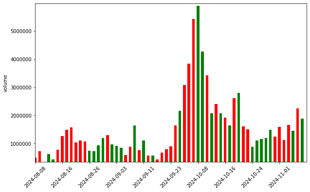

```python
"""
【补充示例】绘制成交量。
"""
import numpy as np
import matplotlib.pyplot as plt
import pandas as pd

df_stockload = pd.read_csv('dataset/000001.SZ.csv',usecols=['trade_date', 'open', 'high', 'low', 'close', 'vol'])

# 设置仅展示最后n天
num = int(input("选择显示的天数：")) #推荐[10,20,60,120,240]
df_stockload = df_stockload.iloc[-num * 2:]

display_start = len(df_stockload) - num
display_end = len(df_stockload)
df_display = df_stockload.iloc[-num:]

df_stockload['trade_date'] = pd.to_datetime(df_stockload['trade_date'], format='%Y%m%d')
df_stockload = df_stockload.set_index('trade_date')


"""
绘制成交量图
"""
fig, ax = plt.subplots(figsize=(10, 6))
ax.set_ylabel("volume")
bar_colors = ['green' if o > c else 'red' for o, c in zip(df_stockload.open, df_stockload.close)]
ax.bar(np.arange(0, display_end), df_stockload.vol,width=0.6,color=bar_colors)
ax.set_ylim(df_display.vol.min(), df_display.vol.max() + 100000)
ax.set_xlim(display_start, display_end)
ax.set_xticks(range(display_start, display_end, num // 10)) # 设置时间显示刻度
for label in ax.xaxis.get_ticklabels():
    label.set_rotation(45)
    label.set_fontsize(10)
ax.set_xticklabels([df_stockload.index.strftime('%Y-%m-%d')[index] for index in ax.get_xticks()])
plt.show()
```

## MACD介绍

MACD（Moving Average Convergence Divergence，移动平均收敛散度指标）主要用于衡量市场的强弱和趋势反转。

MACD的计算包括三个主要部分：

1. **差离值（DIF）**
2. **信号线（DEA 或 MACD Signal）**
3. **MACD柱状图（Histogram）**

#### 1. DIF（差离值）：

DIF差离值（俗称快线）是快速EMA和慢速EMA之间的差值，反映了短期和长期趋势的差异。 快速EMA通常是12日的指数移动平均线，用于反映短期价格走势。

$$ \text{EMA}_{\text{fast}} = \text{EMA}( \text{close}, 12) $$

慢速EMA通常是26日的指数移动平均线，用于反映长期价格走势。

$$ \text{EMA}_{\text{slow}} = \text{EMA}( \text{close}, 26) $$

两者相减即为DIF。

$$ \text{DIF} = \text{EMA}_{\text{fast}} - \text{EMA}_{\text{slow}} $$

#### 2. DEA（信号线）：

DEA信号线（俗称慢线）是DIF的9日指数移动平均线，用于平滑DIF并生成买入或卖出信号。

$$ \text{DEA} = \text{EMA}( \text{DIF}, 9) $$

#### 3. MACD柱状图：

MACD柱状图（Histogram）是DIF和DEA之间的差值，显示了DIF与DEA之间的距离，用于衡量市场的强弱。

$$ \text{MACD Histogram} = \text{DIF} - \text{DEA} $$

以下是常见的基于MACD的信号：

#### 1. **DIF与DEA交叉信号**

MACD最常用的信号来源是 **DIF线**（快速线）与 **DEA线**（慢速线）的交叉。交叉信号通常用于判断市场的买卖时机。

- **金叉（Bullish Crossover）**：
  - **定义**：DIF线从下方突破DEA线。
  - **含义**：这通常被视为一个 **买入信号**，表明市场的短期上涨动能增强，可能会出现上涨趋势。
  - **图形表现**：DIF线（红线）从下方向上突破DEA线（蓝线）。
- **死叉（Bearish Crossover）**：
  - **定义**：DIF线从上方跌破DEA线。
  - **含义**：这通常被视为一个 **卖出信号**，表明市场的短期下跌动能增强，可能会出现下跌趋势。
  - **图形表现**：DIF线（红线）从上方向下突破DEA线（蓝线）。

#### 2. **MACD柱状图（Histogram）信号**

MACD柱状图表示的是 **DIF** 和 **DEA** 之间的差值。它反映了市场动能的变化情况，柱状图的变化可以提供一些重要信号：

- **柱状图增大**：
  - **定义**：当MACD柱状图的高度变大（无论是正柱还是负柱），表示市场动能增加。
  - **含义**：柱状图增大时，如果是正值柱状图增大，表示上涨动能增强；如果是负值柱状图增大，表示下跌动能增强。可以作为趋势延续的信号。
- **柱状图缩小**：
  - **定义**：当MACD柱状图的高度变小，表示市场动能减弱。
  - **含义**：柱状图缩小时，如果是正值柱状图缩小，表示上涨动能减弱；如果是负值柱状图缩小，表示下跌动能减弱。可以作为市场反转或趋势弱化的信号。
- **柱状图从负变正（底背离）**：
  - **定义**：MACD柱状图由负值转为正值。
  - **含义**：这通常是一个 **反转信号**，表明市场的卖出压力开始减弱，可能会迎来上涨的机会。
  - **图形表现**：MACD柱状图从下方（负值）开始逐渐变为正值。
- **柱状图从正变负（顶背离）**：
  - **定义**：MACD柱状图由正值转为负值。
  - **含义**：这通常是一个 **反转信号**，表明市场的买入动力开始减弱，可能会迎来下跌的机会。
  - **图形表现**：MACD柱状图从上方（正值）开始逐渐变为负值。

#### 3. **DIF与价格的背离（Divergence）信号**

背离是MACD分析中的重要信号，通常表明市场的趋势即将发生反转。

- **顶背离（Bearish Divergence）**：
  - **定义**：当价格创出新高时，DIF却未能创出新高。
  - **含义**：这是一个 **卖出信号**，表示尽管价格仍在上升，但上涨动能已经减弱，市场可能会出现反转。
  - **图形表现**：价格形成更高的高点，而MACD的DIF线却形成较低的高点，形成背离。
- **底背离（Bullish Divergence）**：
  - **定义**：当价格创出新低时，DIF却未能创出新低。
  - **含义**：这是一个 **买入信号**，表示尽管价格仍在下跌，但下跌动能已经减弱，市场可能会出现反转。
  - **图形表现**：价格形成更低的低点，而MACD的DIF线却形成较高的低点，形成背离。

#### 4. **MACD柱状图零轴信号**

零轴是MACD分析中的一个重要参考线，表示DIF与DEA线相等的水平。

- **MACD柱状图穿越零轴**：
  - **穿越零轴向上**：当MACD柱状图从负值区域穿越零轴进入正值区域时，通常被认为是一个 **买入信号**。
  - **穿越零轴向下**：当MACD柱状图从正值区域穿越零轴进入负值区域时，通常被认为是一个 **卖出信号**。

#### 5. **DIF与DEA的距离扩展/收缩**

- **DIF和DEA的距离增大**：
  - **含义**： 当DIF与DEA的距离逐渐增大时，表示趋势的动能增加，可能是市场趋势强劲，继续向一个方向发展的信号。
- **DIF和DEA的距离缩小**：
  - **含义**：当DIF与DEA的距离逐渐缩小时，表示趋势的动能减弱，可能是市场即将发生反转或调整。

#### 总结

MACD的信号主要通过以下方式来帮助分析市场趋势：

1. **金叉和死叉**：DIF与DEA线的交叉，提供买卖时机。
2. **柱状图的变化**：柱状图的增大或缩小，提供市场动能变化的信号。
3. **背离**：DIF与价格或柱状图的背离，提示可能的趋势反转。
4. **零轴穿越**：柱状图穿越零轴，确认买入或卖出信号。

通过这些MACD信号，投资者可以判断市场的趋势强度、潜在的反转点以及进场或离场的时机。

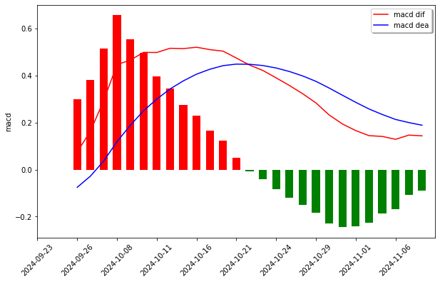

```python
"""
【补充示例】绘制MACD。
"""
import talib
import numpy as np
import matplotlib.pyplot as plt
import pandas as pd

df_stockload = pd.read_csv('dataset/000001.SZ.csv',usecols=['trade_date', 'open', 'high', 'low', 'close', 'vol'])

# 设置仅展示最后n天
num = 30 #推荐[10,20,60,120,240]
df_stockload = df_stockload.iloc[-num * 2:]

display_start = len(df_stockload) - num
display_end = len(df_stockload)
df_display = df_stockload.iloc[-num:]

df_stockload['trade_date'] = pd.to_datetime(df_stockload['trade_date'], format='%Y%m%d')
df_stockload = df_stockload.set_index('trade_date')

fig, ax = plt.subplots(figsize=(10, 6))
ax.set_ylabel("macd")

macd_dif, macd_dea, macd_bar = talib.MACD(df_stockload['close'].values,
                                          fastperiod=12, slowperiod=26, signalperiod=9)

ax.plot(np.arange(0, len(df_stockload.index)), macd_dif, 'red', label='macd dif')
ax.plot(np.arange(0, len(df_stockload.index)), macd_dea, 'blue', label='macd dea')

bar_red = np.where(macd_bar > 0, 2 * macd_bar, 0)
bar_green = np.where(macd_bar < 0, 2 * macd_bar, 0)

# 修改MACD柱状图宽度与成交量一致
ax.bar(np.arange(0, len(df_stockload.index)), bar_red, width=0.6, facecolor='red')
ax.bar(np.arange(0, len(df_stockload.index)), bar_green, width=0.6, facecolor='green')

ax.legend(loc='best', shadow=True, fontsize='10')

ax.set_xlim(display_start, display_end)
ax.set_xticks(range(display_start, display_end, num // 10)) # 设置时间显示刻度
for label in ax.xaxis.get_ticklabels():
    label.set_rotation(45)
    label.set_fontsize(10)
ax.set_xticklabels([df_stockload.index.strftime('%Y-%m-%d')[index] for index in ax.get_xticks()])
plt.show()
```

### KDJ计算公式及信号

KDJ（随机指标）是技术分析中广泛使用的一个指标，常用于判断市场的超买或超卖情况。KDJ由三条线组成：**K线**、**D线** 和 **J线**，这些线基于随机振荡器（Stochastic Oscillator）计算，并通过加权平均计算得出。

#### 1. **KDJ计算公式**

KDJ的计算过程可以分为三个部分：**K线**、**D线** 和 **J线**。

- **K线**：表示当前价格与最近9天的最高价和最低价之间的位置关系。

  $$ K = \frac{(CLOSE - LOW_{9})}{(HIGH_{9} - LOW_{9})} \times 100 $$
  - `CLOSE`：当前的收盘价。
  - `HIGH_9`：最近9天的最高价。
  - `LOW_9`：最近9天的最低价。
- **D线**：是K线的平滑化，即K线的移动平均线。通常使用3日移动平均来平滑K线。

  $$ D = \text{SMA}(K, 3) $$
  - `SMA`：简单移动平均（Simple Moving Average）。
- **J线**：是K线和D线的加权线，常常用来显示更强烈的波动信号。

  $$ J = 3 \times K - 2 \times D $$

### 2. **KDJ信号**

KDJ指标的信号主要由K线、D线和J线的交叉和背离等构成。以下是常见的KDJ信号：

#### 1. **金叉（Bullish Crossover）**

- **定义**：K线从下方穿越D线。
- **含义**：通常认为这是一个 **买入信号**，表示市场可能出现上涨趋势。

#### 2. **死叉（Bearish Crossover）**

- **定义**：K线从上方跌破D线。
- **含义**：通常认为这是一个 **卖出信号**，表示市场可能出现下跌趋势。

#### 3. **J线超买超卖区间信号**

- **J线超买区间（J > 100）**：
  - **定义**：J线值超过100。
  - **含义**：表明市场已经过度买入，可能出现回调或反转。通常这是一个 **卖出信号**。
- **J线超卖区间（J < 0）**：
  - **定义**：J线值低于0。
  - **含义**：表明市场已经过度卖出，可能出现反弹。通常这是一个 **买入信号**。

#### 4. **背离信号（Divergence）**

- **底背离（Bullish Divergence）**：
  - **定义**：当价格创出新低时，KDJ的K线和D线未能创出新低。
  - **含义**：这通常是一个 **反转信号**，表示市场的卖盘力度减弱，价格可能反弹。
- **顶背离（Bearish Divergence）**：
  - **定义**：当价格创出新高时，KDJ的K线和D线未能创出新高。
  - **含义**：这通常是一个 **反转信号**，表示市场的买盘力度减弱，价格可能下跌。

#### 5. **KDJ与价格的同步信号**

- **价格创新高，KDJ也创新高**：表示趋势可能继续，买入信号更强。
- **价格创新低，KDJ也创新低**：表示趋势可能继续，卖出信号更强。

### 3. **KDJ信号的总结**

| **信号** | **解释** |
| --- | --- |
| **金叉（Bullish Crossover）** | K线从下方突破D线，通常是买入信号。 |
| **死叉（Bearish Crossover）** | K线从上方跌破D线，通常是卖出信号。 |
| **J线超买区（J > 100）** | J线值超过100，表明市场过热，可能出现回调或反转，卖出信号。 |
| **J线超卖区（J < 0）** | J线值低于0，表明市场超卖，可能出现反弹，买入信号。 |
| **底背离（Bullish Divergence）** | 价格创出新低，但KDJ未能创出新低，通常是反转信号，可能是买入信号。 |
| **顶背离（Bearish Divergence）** | 价格创出新高，但KDJ未能创出新高，通常是反转信号，可能是卖出信号。 |

通过对KDJ的交叉、背离以及超买超卖的区间进行分析，投资者可以在不同的市场阶段做出相应的交易决策。

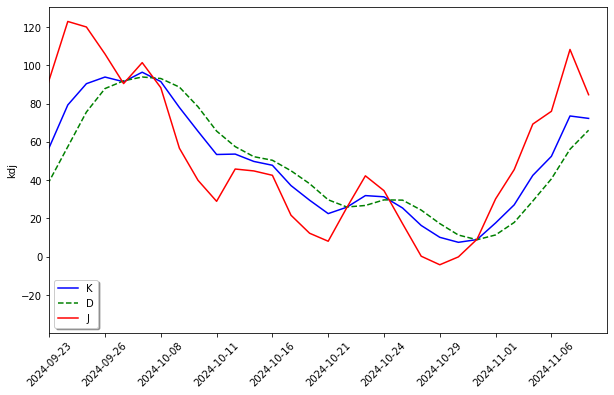

```python
"""
【补充示例】绘制KDJ。
"""
import numpy as np
import matplotlib.pyplot as plt
import pandas as pd

df_stockload = pd.read_csv('dataset/000001.SZ.csv',usecols=['trade_date', 'open', 'high', 'low', 'close', 'vol'])

# 设置仅展示最后n天
num = 30 #推荐[10,20,60,120,240]
df_stockload = df_stockload.iloc[-num * 2:]

display_start = len(df_stockload) - num
display_end = len(df_stockload)
df_display = df_stockload.iloc[-num:]

df_stockload['trade_date'] = pd.to_datetime(df_stockload['trade_date'], format='%Y%m%d')
df_stockload = df_stockload.set_index('trade_date')

fig, ax = plt.subplots(figsize=(10, 6))
ax.set_ylabel("kdj")

df_stockload['K'], df_stockload['D'] = talib.STOCH(df_stockload.high.values,
                                                   df_stockload.low.values,
                                                   df_stockload.close.values,
                                                   fastk_period=9,
                                                   slowk_period=3,
                                                   slowk_matype=0,
                                                   slowd_period=3,
                                                   slowd_matype=0)
df_stockload['J'] = 3 * df_stockload['K'] - 2 * df_stockload['D']

ax.plot(np.arange(0, len(df_stockload.index)), df_stockload['K'], 'blue', label='K')
ax.plot(np.arange(0, len(df_stockload.index)), df_stockload['D'], 'g--', label='D')
ax.plot(np.arange(0, len(df_stockload.index)), df_stockload['J'], 'r-', label='J')
ax.legend(loc='best', shadow=True, fontsize='10')

ax.set_xlim(display_start, display_end)
ax.set_xticks(range(display_start, display_end, num // 10)) # 设置时间显示刻度
ax.set_xlim(display_start, display_end)
ax.set_xticks(range(display_start, display_end, num // 10)) # 设置时间显示刻度
for label in ax.xaxis.get_ticklabels():
    label.set_rotation(45)
    label.set_fontsize(10)
ax.set_xticklabels([df_stockload.index.strftime('%Y-%m-%d')[index] for index in ax.get_xticks()])
plt.show()
```

### RSI（相对强弱指数，Relative Strength Index）

RSI（Relative Strength Index，简称RSI）是由J. Welles Wilder于1978年提出的一个技术分析指标，用于评估价格变化的强度，帮助判断市场的超买或超卖状态。RSI的数值范围为0到100，通常使用14个交易日作为计算周期。

### 1. **RSI计算公式**

RSI的计算过程可以分为以下几个步骤：

1. **计算每个交易日的涨幅和跌幅**：
   - **上涨幅度（U）**：当天的收盘价高于前一天收盘价时的涨幅。
   - **下跌幅度（D）**：当天的收盘价低于前一天收盘价时的跌幅。

   如果当天的收盘价高于前一天，则涨幅 $U = \text{今日收盘价} - \text{昨日收盘价}$，否则涨幅为0；同样，如果当天的收盘价低于前一天，则跌幅 $D = \text{昨日收盘价} - \text{今日收盘价}$，否则跌幅为0。
2. **计算平均涨幅和平均跌幅**：
   - 平均涨幅 $\text{avgU}$ 是过去N日的涨幅的算术平均。
   - 平均跌幅 $\text{avgD}$ 是过去N日的跌幅的算术平均。

   $$ \text{avgU} = \frac{\sum_{i=1}^{N} U_i}{N} $$

   $$ \text{avgD} = \frac{\sum_{i=1}^{N} D_i}{N} $$
3. **计算相对强度（RS）**：
   - 相对强度 $RS$ 是平均涨幅与平均跌幅的比值：

   $$ RS = \frac{\text{avgU}}{\text{avgD}} $$
4. **计算RSI**：
   - 最终的RSI值通过以下公式计算得出：

   $$ RSI = 100 - \frac{100}{1 + RS} $$

### 2. **RSI的常见应用和信号**

RSI的数值范围在0到100之间，通常用于判断市场的超买或超卖状态。以下是几种常见的RSI信号：

#### 1. **超买和超卖区间**

- **超买区（RSI > 70）**：
  - **定义**：RSI值超过70，表示市场可能过度购买，价格可能会出现回调或反转。
  - **含义**：市场的买方力量过强，价格可能即将出现下跌。
- **超卖区（RSI < 30）**：
  - **定义**：RSI值低于30，表示市场可能过度卖出，价格可能会出现反弹或反转。
  - **含义**：市场的卖方力量过强，价格可能即将出现上涨。

#### 2. **RSI背离信号**

- **底背离（Bullish Divergence）**：
  - **定义**：价格创出新低，但RSI未能创出新低，表示市场下跌动能减弱，可能会有反弹。
  - **含义**：当价格创出新低时，RSI未创出新低，暗示市场可能即将反转，产生买入信号。
- **顶背离（Bearish Divergence）**：
  - **定义**：价格创出新高，但RSI未能创出新高，表示市场上涨动能减弱，可能会出现回调。
  - **含义**：当价格创出新高时，RSI未创出新高，暗示市场可能即将反转，产生卖出信号。

#### 4. **RSI的波动性信号**

- **RSI震荡区间**：
  - **定义**：RSI在一定范围内震荡，表明市场处于整理阶段，短期内可能没有明确的趋势。
  - **含义**：如果RSI持续在40-60区间内波动，说明市场缺乏方向性，建议等待突破信号。

### 3. **RSI信号总结**

| **信号** | **解释** |
| --- | --- |
| **超买（RSI > 70）** | 市场可能过度购买，价格可能出现回调，形成 **卖出信号**。 |
| **超卖（RSI < 30）** | 市场可能过度卖出，价格可能出现反弹，形成 **买入信号**。 |
| **RSI底背离（Bullish Divergence）** | 价格创出新低时，RSI未创出新低，表明市场反转的可能，通常是 **买入信号**。 |
| **RSI顶背离（Bearish Divergence）** | 价格创出新高时，RSI未创出新高，表明市场反转的可能，通常是 **卖出信号**。 |
| **RSI突破50（从下到上）** | RSI从50以下突破50，表明市场上涨趋势可能开始，通常是 **买入信号**。 |
| **RSI跌破50（从上到下）** | RSI从50以上跌破50，表明市场下跌趋势可能开始，通常是 **卖出信号**。 |

RSI是一个非常有效的工具，用于判断市场的超买和超卖状态，以及捕捉市场趋势的反转。通过分析RSI的超买、超卖、背离和突破等信号，投资者可以根据市场的动能变化做出相应的交易决策。

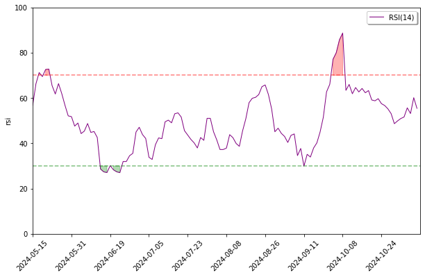

```python
"""
【补充示例】绘制RSI。
"""

import numpy as np
import matplotlib.pyplot as plt
import pandas as pd

df_stockload = pd.read_csv('dataset/000001.SZ.csv',usecols=['trade_date', 'open', 'high', 'low', 'close', 'vol'])

# 设置仅展示最后n天
num = 120 #推荐[10,20,60,120,240]
df_stockload = df_stockload.iloc[-num * 2:]

display_start = len(df_stockload) - num
display_end = len(df_stockload)
df_display = df_stockload.iloc[-num:]

df_stockload['trade_date'] = pd.to_datetime(df_stockload['trade_date'], format='%Y%m%d')
df_stockload = df_stockload.set_index('trade_date')

fig, ax = plt.subplots(figsize=(10, 6))
ax.set_ylabel("rsi")

df_stockload['RSI'] = talib.RSI(df_stockload['close'].values, timeperiod=14)

ax.plot(np.arange(0, len(df_stockload.index)), df_stockload['RSI'],
               'purple', label='RSI(14)', lw=1.0)

# 添加超买超卖线
ax.axhline(70, linestyle='--', color='red', alpha=0.5)
ax.axhline(30, linestyle='--', color='green', alpha=0.5)

# 填充超买超卖区域
ax.fill_between(np.arange(0, len(df_stockload.index)),
                       df_stockload['RSI'], 70,
                       where=(df_stockload['RSI'] >= 70),
                       color='red', alpha=0.3)
ax.fill_between(np.arange(0, len(df_stockload.index)),
                       df_stockload['RSI'], 30,
                       where=(df_stockload['RSI'] <= 30),
                       color='green', alpha=0.3)

ax.legend(loc='best', shadow=True, fontsize='10')


ax.set_xlim(display_start, display_end)
ax.set_ylim(0, 100)  # RSI范围固定为0-100
ax.set_xticks(range(display_start, display_end, num // 10)) # 设置时间显示刻度
ax.set_xticklabels(
    [df_stockload.index.strftime('%Y-%m-%d')[index] for index in ax.get_xticks()])

for label in ax.xaxis.get_ticklabels():
    label.set_rotation(45)
    label.set_fontsize(10)

plt.show()
```

```
选择显示的天数：60
创建图框
绘制k线图
绘制移动平均线
绘制成交量图
绘制MACD图
绘制KDJ图
绘制RSI图
```

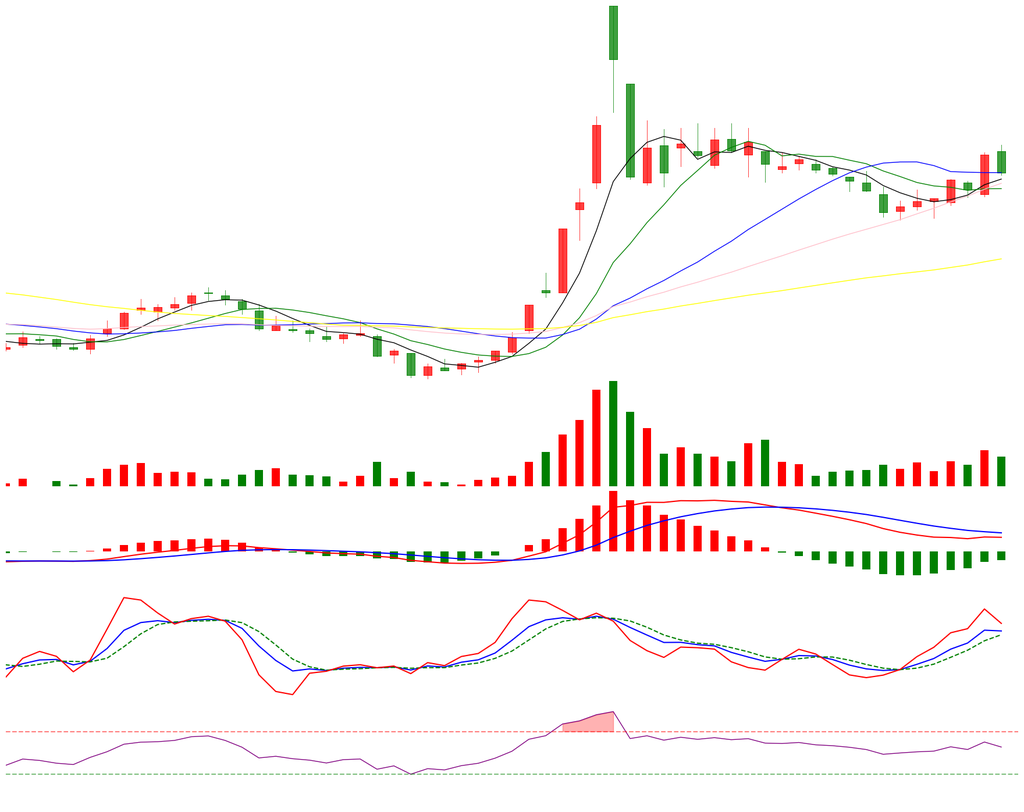

```python
"""
【补充示例】绘制五张图合并。
"""

import talib
import numpy as np
import pandas as pd
import matplotlib.pyplot as plt
import matplotlib.gridspec as gridspec
import matplotlib.dates as mdates
import mpl_finance as mpf

np.seterr(divide='ignore', invalid='ignore')  # 忽略warning
plt.rcParams['font.sans-serif'] = ['SimHei']  # 用来正常显示中文标签
plt.rcParams['axes.unicode_minus'] = False  # 用来正常显示负号

fig = plt.figure(figsize=(20, 16), dpi=100, facecolor="white")  # 调整了fig大小以容纳RSI图表

ts_code = '000001.SZ'  # 股票代码

# 通过列名指定要读取的列
df_stockload = pd.read_csv('dataset/' + ts_code + '.csv', usecols=['trade_date', 'open', 'high', 'low', 'close', 'vol'])

# 设置仅展示最后n天
num = int(input("选择显示的天数：")) #10 20 60 120 240

df_stockload = df_stockload.iloc[-num * 2:]

display_start = len(df_stockload) - num
display_end = len(df_stockload)
df_display = df_stockload.iloc[-num:]

df_stockload['trade_date'] = pd.to_datetime(df_stockload['trade_date'], format='%Y%m%d')
df_stockload = df_stockload.set_index('trade_date')
print("创建图框")

# 子图布局
gs = gridspec.GridSpec(5, 1, left=0.08, bottom=0.1, right=0.95, top=0.96,  # 边界微调
                       wspace=0, hspace=0,  # 增加子图间距
                       height_ratios=[3.5, 1, 1, 1, 1])

graph_KAV = fig.add_subplot(gs[0, :])
graph_VOL = fig.add_subplot(gs[1, :])
graph_MACD = fig.add_subplot(gs[2, :])
graph_KDJ = fig.add_subplot(gs[3, :])
graph_RSI = fig.add_subplot(gs[4, :])  # 新增RSI子图

for ax in [graph_KAV, graph_VOL, graph_MACD, graph_KDJ, graph_RSI]:
    # 隐藏所有spines（边框）
    ax.spines['top'].set_visible(False)
    ax.spines['right'].set_visible(False)
    ax.spines['bottom'].set_visible(False)
    ax.spines['left'].set_visible(False)

# 隐藏X轴标签代码（保持对RSI的特殊处理）
for ax in [graph_KAV, graph_VOL, graph_MACD, graph_KDJ]:
    ax.tick_params(axis='both', which='both', length=0)  # 隐藏刻度线
    ax.set_xticks([])
    ax.set_yticks([])

# RSI子图特殊处理（保留x轴日期标签）
graph_RSI.tick_params(axis='both', which='both', length=0)  # 隐藏刻度线
graph_RSI.set_yticks([])  # 隐藏y轴刻度

# 绘制K线图
print("绘制k线图")
mpf.candlestick2_ochl(graph_KAV, df_stockload.open, df_stockload.close,
                      df_stockload.high, df_stockload.low, width=0.5,
                      colorup='r', colordown='g')  # 绘制K线走势

# 绘制移动平均线图
print("绘制移动平均线")
df_stockload['Ma5'] = df_stockload.close.rolling(window=5).mean()
df_stockload['Ma10'] = df_stockload.close.rolling(window=10).mean()
df_stockload['Ma20'] = df_stockload.close.rolling(window=20).mean()
df_stockload['Ma30'] = df_stockload.close.rolling(window=30).mean()
df_stockload['Ma60'] = df_stockload.close.rolling(window=60).mean()

graph_KAV.plot(np.arange(0, display_end), df_stockload['Ma5'], 'black', label='M5', lw=1.0)
graph_KAV.plot(np.arange(0, display_end), df_stockload['Ma10'], 'green', label='M10', lw=1.0)
graph_KAV.plot(np.arange(0, display_end), df_stockload['Ma20'], 'blue', label='M20', lw=1.0)
graph_KAV.plot(np.arange(0, display_end), df_stockload['Ma30'], 'pink', label='M30', lw=1.0)
graph_KAV.plot(np.arange(0, display_end), df_stockload['Ma60'], 'yellow', label='M60', lw=1.0)

# graph_KAV.grid()
# graph_KAV.legend(loc='best')
# graph_KAV.set_title(f"{ts_code} {num}天日K")
graph_KAV.set_ylim(df_display.low.min() - 1, df_display.high.max() + 1)
# graph_KAV.set_ylabel(u"价格")
graph_KAV.set_xlim(display_start, display_end)

# 绘制成交量图
print("绘制成交量图")
bar_width = 0.5  # 根据显示天数动态调整

graph_VOL.bar(np.arange(0, display_end), df_stockload.vol,
             width=bar_width,  color=['g' if df_stockload.open[x] > df_stockload.close[x] else 'r' for x in range(0, len(df_stockload.index))])

# graph_VOL.set_ylabel(u"成交量")
graph_VOL.set_ylim(df_display.vol.min(), df_display.vol.max() + 100000)
graph_VOL.set_xlim(display_start, display_end)
graph_VOL.set_xticks(range(display_start, display_end, num // 10)) # 设置时间显示刻度

# 绘制MACD
print("绘制MACD图")
macd_dif, macd_dea, macd_bar = talib.MACD(df_stockload['close'].values,
                                          fastperiod=12, slowperiod=26, signalperiod=9)

graph_MACD.plot(np.arange(0, len(df_stockload.index)), macd_dif, 'red', label='macd dif')
graph_MACD.plot(np.arange(0, len(df_stockload.index)), macd_dea, 'blue', label='macd dea')

bar_red = np.where(macd_bar > 0, 2 * macd_bar, 0)
bar_green = np.where(macd_bar < 0, 2 * macd_bar, 0)

# 修改MACD柱状图宽度与成交量一致
graph_MACD.bar(np.arange(0, len(df_stockload.index)), bar_red, width=bar_width, facecolor='red')
graph_MACD.bar(np.arange(0, len(df_stockload.index)), bar_green, width=bar_width, facecolor='green')

# graph_MACD.legend(loc='best', shadow=True, fontsize='10')
# graph_MACD.set_ylabel("MACD")
graph_KAV.set_ylim(df_display.low.min(), df_display.high.max())
graph_MACD.set_xlim(display_start, display_end)
graph_MACD.set_xticks(range(display_start, display_end, num // 10)) # 设置时间显示刻度

# 绘制KDJ
print("绘制KDJ图")
df_stockload['K'], df_stockload['D'] = talib.STOCH(df_stockload.high.values,
                                                   df_stockload.low.values,
                                                   df_stockload.close.values,
                                                   fastk_period=9,
                                                   slowk_period=3,
                                                   slowk_matype=0,
                                                   slowd_period=3,
                                                   slowd_matype=0)
df_stockload['J'] = 3 * df_stockload['K'] - 2 * df_stockload['D']

graph_KDJ.plot(np.arange(0, len(df_stockload.index)), df_stockload['K'], 'blue', label='K')
graph_KDJ.plot(np.arange(0, len(df_stockload.index)), df_stockload['D'], 'g--', label='D')
graph_KDJ.plot(np.arange(0, len(df_stockload.index)), df_stockload['J'], 'r-', label='J')
# graph_KDJ.legend(loc='best', shadow=True, fontsize='10')
# graph_KDJ.set_ylabel(u"KDJ")
graph_KDJ.set_xlim(display_start, display_end)
graph_KDJ.set_xticks(range(display_start, display_end, num // 10)) # 设置时间显示刻度

# 绘制RSI指标
print("绘制RSI图")
df_stockload['RSI'] = talib.RSI(df_stockload['close'].values, timeperiod=14)

graph_RSI.plot(np.arange(0, len(df_stockload.index)), df_stockload['RSI'],
               'purple', label='RSI(14)', lw=1.0)

# 添加超买超卖线
graph_RSI.axhline(70, linestyle='--', color='red', alpha=0.5)
graph_RSI.axhline(30, linestyle='--', color='green', alpha=0.5)

# 填充超买超卖区域
graph_RSI.fill_between(np.arange(0, len(df_stockload.index)),
                       df_stockload['RSI'], 70,
                       where=(df_stockload['RSI'] >= 70),
                       color='red', alpha=0.3)
graph_RSI.fill_between(np.arange(0, len(df_stockload.index)),
                       df_stockload['RSI'], 30,
                       where=(df_stockload['RSI'] <= 30),
                       color='green', alpha=0.3)

# graph_RSI.legend(loc='best', shadow=True, fontsize='10')
# graph_RSI.set_ylabel(u"RSI")
# graph_RSI.set_xlabel("日期")
graph_RSI.set_xlim(display_start, display_end)
graph_RSI.set_ylim(0, 100)  # RSI范围固定为0-100
graph_RSI.set_xticks(range(display_start, display_end, num // 10)) # 设置时间显示刻度
graph_RSI.set_xticklabels(
    [df_stockload.index.strftime('%Y-%m-%d')[index] for index in graph_RSI.get_xticks()])

# 隐藏上方子图的X轴标签
for label in graph_KAV.xaxis.get_ticklabels():
    label.set_visible(False)
for label in graph_VOL.xaxis.get_ticklabels():
    label.set_visible(False)
for label in graph_MACD.xaxis.get_ticklabels():
    label.set_visible(False)
for label in graph_KDJ.xaxis.get_ticklabels():
    label.set_visible(False)
for label in graph_RSI.xaxis.get_ticklabels():
    label.set_visible(False)

# # 仅显示最下方子图的X轴标签
# for label in graph_RSI.xaxis.get_ticklabels():
#     label.set_rotation(45)
#     label.set_fontsize(10)

# plt.savefig(f'Kline_{ts_code}_{num}天日K.jpg')
plt.show()
plt.close()
```

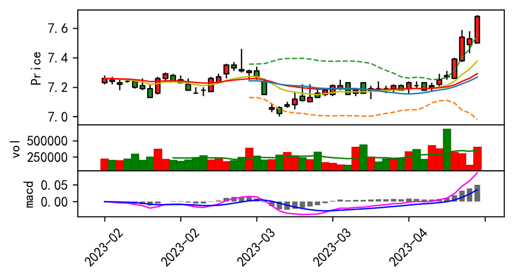

```python
"""
【示例7-20】添加MACD指标的K线图。
"""
# 计算macd的数据
exp12 = df['close'].ewm(span=12, adjust=False).mean()
exp26 = df['close'].ewm(span=26, adjust=False).mean()
DIF = exp12 - exp26
DEA = DIF.ewm(span=9, adjust=False).mean()
MACD = DIF - DEA
# 设置多个需要添加至子图的make_addplot对象列表
add_plot = [
    mpf.make_addplot(exp12, type='line',width=1, color='y'),
    mpf.make_addplot(exp26, type='line',width=1, color='r'),
    mpf.make_addplot(MACD, type='bar', width=0.7, panel=2, color='dimgray', alpha=1,secondary_y=False),
    mpf.make_addplot(DIF, panel=2, color='fuchsia',width=1, secondary_y=False),
    mpf.make_addplot(DEA, panel=2, color='b',width=1, secondary_y=False,ylabel='macd'),
    mpf.make_addplot(df['volume'].rolling(10).mean(), panel=1,width=1, color='g',ylabel='macd'),
    mpf.make_addplot(mid,width=1, linestyle='-'),
    mpf.make_addplot(low,width=1, linestyle='--'),
    mpf.make_addplot(up,width=1, linestyle='--')
    ]
# 可视化输出K线主图
fig,ax = mpf.plot(df,
                  datetime_format='%Y-%m',
                  returnfig=True,
                  figsize=(6, 3),
                  type='candle',
                  style=style,
                  volume=True,
                  addplot=add_plot,
                  ylabel_lower='vol',    # 设置成交量图的y轴标签
                  main_panel=0,          # 设置主图编号为0
                  volume_panel=1,        # 设置成交量图编号为1
                 )

fig.show()
```

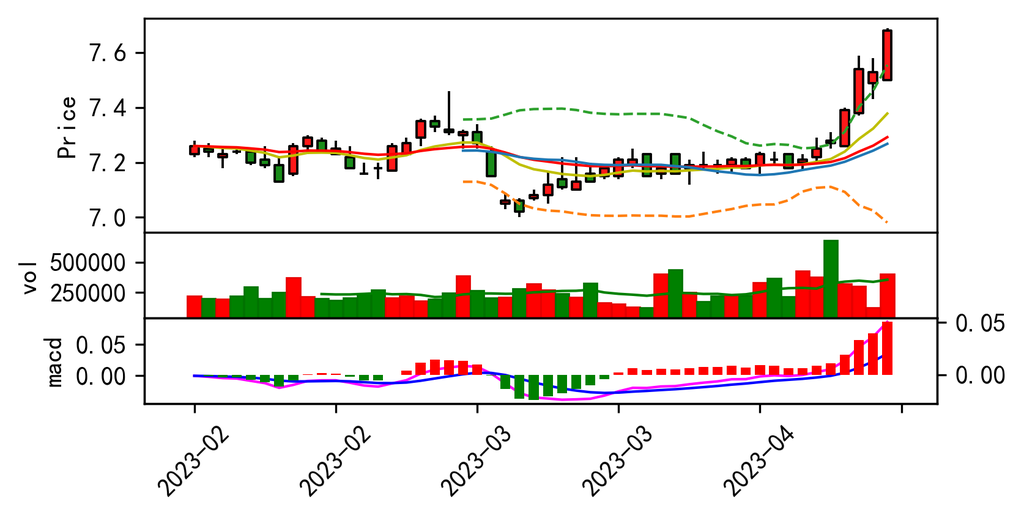

```python
"""
【示例】双色MACD指标的K线图。
"""
# 计算两组MACD值，分别代表0轴上方MACD柱线与0轴下方MACD柱线
MACD = DIF - DEA
MACD[MACD < 0] = None
MACD_positive = MACD
MACD = DIF - DEA
MACD[MACD >= 0] = None
MACD_negative = MACD

# 设置多个需要添加至子图的make_addplot对象列表
add_plot = [
    mpf.make_addplot(exp12, type='line',width=1, color='y'),
    mpf.make_addplot(exp26, type='line',width=1, color='r'),
    mpf.make_addplot(MACD_negative, type='bar', width=0.7, panel=2, color='g', alpha=1,secondary_y=True),
    mpf.make_addplot(MACD_positive, type='bar', width=0.7, panel=2, color='r', alpha=1, secondary_y=True),
    mpf.make_addplot(DIF, panel=2, color='fuchsia',width=1, secondary_y=False),
    mpf.make_addplot(DEA, panel=2, color='b',width=1, secondary_y=False,ylabel='macd'),
    mpf.make_addplot(df['volume'].rolling(10).mean(), panel=1,width=1, color='g',ylabel='macd'),
    mpf.make_addplot(mid,width=1, linestyle='-'),
    mpf.make_addplot(low,width=1, linestyle='--'),
    mpf.make_addplot(up,width=1, linestyle='--')
    ]
# 可视化输出K线主图
fig,ax = mpf.plot(df,
                  datetime_format='%Y-%m',
                  returnfig=True,
                  figsize=(6, 3),
                  type='candle',
                  style=style,
                  volume=True,
                  addplot=add_plot,
                  ylabel_lower='vol',    # 设置成交量图的y轴标签
                  main_panel=0,          # 设置主图编号为0
                  volume_panel=1,        # 设置成交量图编号为1
                 )

fig.show()
```

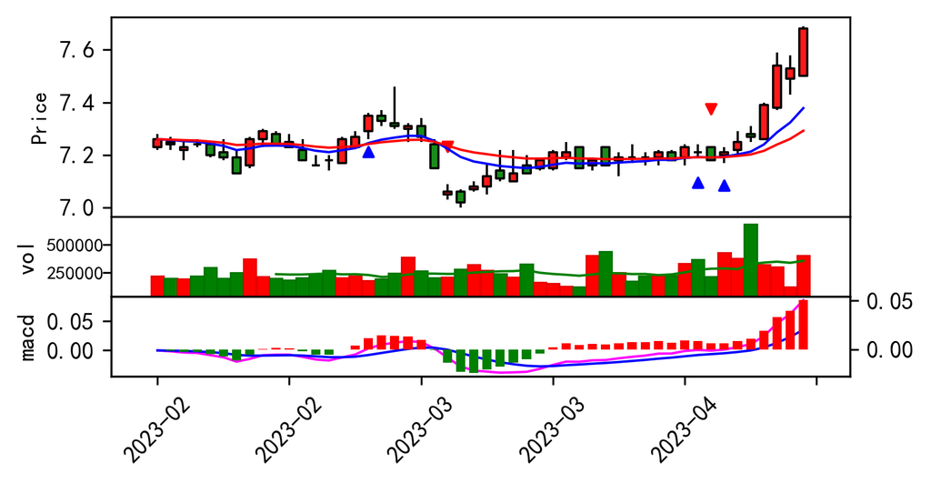

```python
"""
【示例】添加交易信号的K线图。
"""
import pandas as pd
import mplfinance as mpf
import matplotlib.pyplot as plt
from talib import BBANDS
import numpy as np

df_data = pd.read_csv('d:/OneDrive/Python金融量化分析数据文件/600000.csv'
                      ,parse_dates=['trade_date'],
                      index_col='trade_date')
df_data = df_data.iloc[-50:]
# 设置mpf库MarketColors对象，包括K线颜色信息
my_color = mpf.make_marketcolors(
    up='red',           # 表示上涨K线的颜色
    down='green',       # 表示下跌K线的颜色
    edge='black',       # 表示K线的边缘颜色
    wick='black',       # 表示K线上下影线的颜色
    volume='inherit')   # 表示成交量条的颜色
# 将MarketColors对象设置为mpf.make_mpf_style参数
style = mpf.make_mpf_style(
    marketcolors=my_color,          # 设置MarketClors参数
    rc={# 设置中文显示为简体黑体
        'font.family': 'SimHei',
        # 设置负号正常显示
        'axes.unicode_minus': 'False',
        # 设置清晰度
       'figure.dpi':300})
# 计算布林带指标
up, mid, low = BBANDS(df_data['close'],
                      timeperiod=20,
                      nbdevup=2,
                      nbdevdn=2,
                      matype=0)
upline = mpf.make_addplot(up, width=1, type='line', panel=0, alpha=0.9,)
midline = mpf.make_addplot(mid, linestyle='-')
lowline = mpf.make_addplot(low, linestyle='--')
# 计算macd的数据
exp12 = df_data['close'].ewm(span=12, adjust=False).mean()
exp26 = df_data['close'].ewm(span=26, adjust=False).mean()
DIF = exp12 - exp26
DEA = DIF.ewm(span=9, adjust=False).mean()
# 计算两组MACD值，分别代表0轴上方MACD柱线与0轴下方MACD柱线
MACD = DIF - DEA
MACD[MACD < 0] = None
MACD_positive = MACD
MACD = DIF - DEA
MACD[MACD >= 0] = None
MACD_negative = MACD
# 设置买卖交易标记作图y轴数值
high_mark = df_data.high.apply(lambda x:x*1.02)
low_mark = df_data.high.apply(lambda x:x*0.98)
# 计算买入信号
df_data['buy'] = np.where(((exp12.shift(1)<exp26.shift(1)) & (exp12>=exp26)),low_mark,np.nan)
buy_mark = df_data['buy']
# 计算卖出信号
df_data['sell'] = np.where(((exp12.shift(1)>exp26.shift(1)) & (exp12<=exp26)),high_mark,np.nan)
sell_mark = df_data['sell']
# 设置买入信号与卖出信号序列添加至子图的make_addplot对象列表，不设置panel参数值，默认在主图显示。
add_plot = [
    mpf.make_addplot(sell_mark, type='scatter', marker='v',color='r'),
    mpf.make_addplot(buy_mark, type='scatter', marker='^',color='b'),
    mpf.make_addplot(exp12, type='line',width=1, color='b'),
    mpf.make_addplot(exp26, type='line',width=1, color='r'),
    mpf.make_addplot(MACD_negative, type='bar', width=0.7, panel=2, color='g', alpha=1,secondary_y=True),
    mpf.make_addplot(MACD_positive, type='bar', width=0.7, panel=2, color='r', alpha=1, secondary_y=True),
    mpf.make_addplot(DIF, panel=2, color='fuchsia',width=1, secondary_y=False),
    mpf.make_addplot(DEA, panel=2, color='b',width=1, secondary_y=False,ylabel='macd'),
    mpf.make_addplot(df_data['volume'].rolling(10).mean(), panel=1,width=1, color='g',ylabel='macd'),
    ]
# 可视化输出K线主图
fig,ax = mpf.plot(df_data,
                  datetime_format='%Y-%m',
                  returnfig=True,
                  figsize=(6, 3),
                  type='candle',
                  style=style,
                  volume=True,
                  addplot=add_plot,
                  ylabel_lower='vol',   # 设置成交量图的y轴标签
                  main_panel=0,          # 设置主图编号为0
                  volume_panel=1,        # 设置成交量图编号为1
                 )
# title = '图 7-7：添加买卖信号的K线图（600000.SH）'
# fig.suptitle(title,              # title内容
#              y=0.0,                 # 设置title显示的垂直位置（比例）
#              fontsize=12,          # 设置title字体大小
#              fontweight='bold')   # 设置title字体粗细

ax[2].tick_params(axis='x',           # 说明设的坐标轴为x轴
                  labelrotation=20,     # 坐标标签倾斜45°
                  labelsize=8,           # 设置坐标标签字体大小
                  pad=-5)                 # 设置靠近坐标的距离，负值表示与坐标轴贴近
ax[2].tick_params(axis='y', labelsize=8, pad=-0.5)
# ax[0].grid()
ax[0].set_ylabel('Price', fontsize=9)
plt.show()
```

## 前置准备：统一数据读取（只运行一次）

```python
# yf文档：https://www.aidoczh.com/yfinance/reference/yfinance.ticker_tickers.html
# talib文档：https://ta-lib.org/functions/
# tushare文档：https://tushare.pro/document/1

import os
# os.environ["YFINANCE_DISABLE_KEYRING"] = "1"  # 禁用keyring，解决yfinance报错
# proxy = 'http://127.0.0.1:7897' # 挂梯子代理设置，否则不能用yf
# os.environ['HTTP_PROXY'] = proxy
# os.environ['HTTPS_PROXY'] = proxy
# import yfinance as yf
import talib
import pandas as pd
import matplotlib.pyplot as plt
import numpy as np
import tushare as ts

# 设置中文显示
plt.rcParams["font.sans-serif"] = ["SimHei"]
plt.rcParams["axes.unicode_minus"] = False

# ---------------------- 1. 获取行情数据 + 严格数据校验 ----------------------
stock_code = "600519.SH"  # 贵州茅台（A股）
start_date = "20240101"  # Tushare 日期格式要求：YYYYMMDD（无横杠）
# end_date 可选：如果要指定结束日期，格式同上，例如 end_date="20251110"
ts.set_token('7c0a9136f16b24498a63ba46c9cd534bc9428f6d4c9d1f711294c911')
pro = ts.pro_api()

# 获取数据（如果要加结束日期，添加 end_date=end_date 参数）
df = pro.daily(ts_code=stock_code, start_date=start_date)

# ---------------------- 核心：df 排序步骤 ----------------------
# 1. 将 trade_date（字符串格式 YYYYMMDD）转为 datetime 类型（便于正确排序）
df["trade_date"] = pd.to_datetime(df["trade_date"])

# 2. 按 trade_date 升序排序（ oldest → newest，时间从早到晚）
# ascending=True：升序（默认）；ascending=False：降序（时间从晚到早）
df = df.sort_values(by="trade_date", ascending=True)

# 3. （可选但推荐）将 trade_date 设为索引，后续指标计算更方便
df = df.set_index("trade_date")

# ---------------------- 后续数据处理（保持之前的逻辑）----------------------
# 重命名列名，适配后续指标计算（Tushare 列名为小写，统一为大写）
df.rename(columns={
    "open": "Open",
    "high": "High",
    "low": "Low",
    "close": "Close",
    "vol": "Volume"  # Tushare 成交量列名是 vol，对应之前的 Volume
}, inplace=True)

# 保留核心列
df = df[["Open", "High", "Low", "Close", "Volume"]].copy()

# 数据清洗：强制数值类型+去异常值
for col in df.columns:
    df[col] = pd.to_numeric(df[col], errors="coerce")
df = df.dropna()  # 去除 NaN 行
df = df.drop_duplicates()  # 去除重复行
df = df.replace([np.inf, -np.inf], np.nan).dropna()  # 去除无穷大值

# 长度校验（至少 28 行，满足 14 期 DMI 计算）
min_data_len = 28
if len(df) < min_data_len:
    raise ValueError(f"数据长度不足！至少需要 {min_data_len} 行，当前仅 {len(df)} 行")

print("数据获取并排序成功：")
print(f"数据行数：{len(df)}")
print(f"日期范围：{df.index.min()} ~ {df.index.max()}")  # 排序后索引是 datetime 类型，直接显示日期
print("前5行数据（排序后从最早日期开始）：")
print(df.head())

# # 用yfinance获取数据（若仍有问题，换本地数据，看下面全家桶代码）
# df = yf.download(stock_code, start=start_date)
# # 按位置取列+强制重命名，确保列是Series且无重复
# df = df.iloc[:, [0,1,2,3,4]].copy()
# df.columns = ["Open", "High", "Low", "Close", "Volume"]

# # 数据清洗+类型转换（TA-Lib 要求 float64）
# for col in df.columns:
#     df[col] = pd.to_numeric(df[col], errors="coerce")
# df = df.dropna().drop_duplicates().replace([np.inf, -np.inf], np.nan).dropna()

# 提取基础数据（所有指标共用）
high = df["High"].values.ravel().astype(np.float64)
low = df["Low"].values.ravel().astype(np.float64)
close = df["Close"].values.ravel().astype(np.float64)
volume = df["Volume"].values.ravel().astype(np.float64)

print("数据准备完成，行数：", len(df))
print("日期范围：", df.index.min(), "~", df.index.max())
```

```
数据获取并排序成功：
数据行数：449
日期范围：2024-01-02 00:00:00 ~ 2025-11-11 00:00:00
前5行数据（排序后从最早日期开始）：
               Open     High      Low    Close    Volume
trade_date
2024-01-02  1715.00  1718.19  1678.10  1685.01  32156.44
2024-01-03  1681.11  1695.22  1676.33  1694.00  20229.29
2024-01-04  1693.00  1693.00  1662.93  1669.00  21551.07
2024-01-05  1661.33  1678.66  1652.11  1663.36  20242.86
2024-01-08  1661.00  1662.00  1640.01  1643.99  25586.20
数据准备完成，行数： 449
日期范围： 2024-01-02 00:00:00 ~ 2025-11-11 00:00:00
```

## 公式

### 1. DMI（动向指标）

核心公式（标准化计算步骤）

1.**计算 ±DM（动向值）**： $$ +DM = \text{Max}(H_t - H_{t-1}, 0) $$ $$ -DM = \text{Max}(L_{t-1} - L_t, 0) $$

其中，$H_t$ 和 $L_t$ 分别为当前时段的最高价和最低价，$H_{t-1}$ 和 $L_{t-1}$ 分别为前一时段的最高价和最低价。

2.**计算 TR（真实波幅）**： $$ TR = \text{Max}(H_t - L_t, |H_t - C_{t-1}|, |L_t - C_{t-1}|) $$ 其中，$C_{t-1}$ 为前一时段的收盘价。

3.**计算 +DI、-DI（动向指数）**： $$ +DI_t = \frac{\text{MA}(+DM_t)}{\text{MA}(TR_t)} \times 100 $$ $$-DI_t = \frac{\text{MA}(-DM_t)}{\text{MA}(TR_t)} \times 100$$ 其中，MA 为N日移动平均。

4.**计算 DX（趋向指数）**： $$DX_t = \frac{|+DI_t - (-DI_t)|}{(+DI_t + (-DI_t))} \times 100$$ 其中，分母为0时，取0。

5.**计算 ADX（平均趋向指数）**：

$$ADX_t = \text{MA}(DX_t)$$

其中，MA 为N日移动平均。

6.**计算 ADXR（趋向指数评级）**： $$ADXR_t = \frac{ADX_t + ADX_{t-n}}{2}$$ 其中，$n$ 为指定的周期。

核心用途

- 判断趋势强度：ADX > 25 → 趋势强烈（多头 / 空头）；ADX < 20 → 无明显趋势（震荡市）；
- 判断趋势方向：+DI > -DI → 多头趋势；+DI < -DI → 空头趋势；
- 实战场景：避免在 ADX <20 时交易（震荡市易亏损），ADX> 25 且 +DI 上穿 -DI 时可顺势做多。

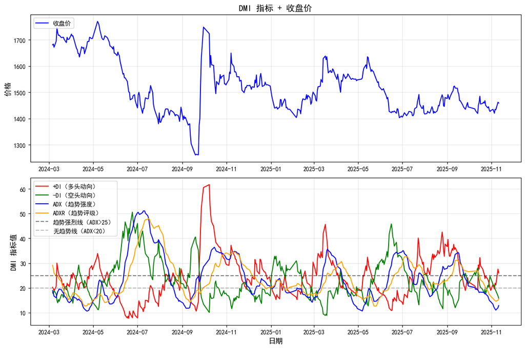

```
DMI 最新5个交易日信号：
              Close        +DI        -DI        ADX   趋势判断
trade_date
2025-11-05  1420.08  19.579028  21.173978  11.886165  无明显趋势
2025-11-06  1435.13  21.897297  19.502539  11.450329  无明显趋势
2025-11-07  1433.33  21.167249  18.852330  11.045625  无明显趋势
2025-11-10  1462.30  27.598940  16.746805  12.004626  无明显趋势
2025-11-11  1458.99  26.021674  15.789732  12.895128  无明显趋势
```

```python
df["+DI"] = talib.PLUS_DI(high, low, close, timeperiod=14)  # 单独计算+DI
df["-DI"] = talib.MINUS_DI(high, low, close, timeperiod=14)  # 单独计算-DI
df["ADX"] = talib.ADX(high, low, close, timeperiod=14)      # 单独计算ADX
df["ADXR"] = talib.ADXR(high, low, close, timeperiod=14)    # 单独计算ADXR

# 去除 NaN，仅保留有效数据
dmi_df = df[["Close", "+DI", "-DI", "ADX", "ADXR"]].dropna()

# 2. 单独画图（2个子图：价格+DMI核心指标）
fig, (ax1, ax2) = plt.subplots(2, 1, figsize=(12, 8), gridspec_kw={"height_ratios": [1, 1]})

# 子图1：收盘价（参考）
ax1.plot(dmi_df.index, dmi_df["Close"], color="blue", linewidth=1.5, label="收盘价")
ax1.set_title("DMI 指标 + 收盘价", fontsize=14)
ax1.set_ylabel("价格", fontsize=12)
ax1.legend(loc="upper left")
ax1.grid(True, alpha=0.3)

# 子图2：+DI/-DI/ADX/ADXR
ax2.plot(dmi_df.index, dmi_df["+DI"], color="red", linewidth=1.5, label="+DI（多头动向）")
ax2.plot(dmi_df.index, dmi_df["-DI"], color="green", linewidth=1.5, label="-DI（空头动向）")
ax2.plot(dmi_df.index, dmi_df["ADX"], color="blue", linewidth=1.5, label="ADX（趋势强度）")
ax2.plot(dmi_df.index, dmi_df["ADXR"], color="orange", linewidth=1.5, label="ADXR（趋势评级）")
ax2.axhline(y=25, color="black", linestyle="--", alpha=0.5, label="趋势强烈线（ADX>25）")
ax2.axhline(y=20, color="gray", linestyle="--", alpha=0.5, label="无趋势线（ADX<20）")
ax2.set_ylabel("DMI 指标值", fontsize=12)
ax2.set_xlabel("日期", fontsize=12)
ax2.legend(loc="upper left")
ax2.grid(True, alpha=0.3)

plt.tight_layout()
plt.show()

# 输出关键信号
dmi_df["趋势判断"] = dmi_df.apply(
    lambda x: "多头趋势" if (x["ADX"] > 25 and x["+DI"] > x["-DI"])
    else ("空头趋势" if (x["ADX"] > 25 and x["+DI"] < x["-DI"])
    else "无明显趋势"), axis=1
)
print("DMI 最新5个交易日信号：")
print(dmi_df[["Close", "+DI", "-DI", "ADX", "趋势判断"]].tail())
```

### 2. OBV（能量潮指标）

OBV（On-Balance Volume，能量潮）是通过将成交量与价格变动结合来反映市场的买卖力量。其计算公式如下：

1. **OBV计算公式**：
   - 如果当前收盘价 $C_t$ 高于前一收盘价 $C_{t-1}$，则：

     $$OBV_t = OBV_{t-1} + V_t$$

     其中，$V_t$ 是当前的成交量。
   - 如果当前收盘价 $C_t$ 低于前一收盘价 $C_{t-1}$，则：

     $$OBV_t = OBV_{t-1} - V_t$$
   - 如果当前收盘价 $C_t$ 等于前一收盘价 $C_{t-1}$，则：

     $$OBV_t = OBV_{t-1}$$
2. **初始OBV值**：
   - 初始时，通常取 $OBV_0 = 0$ ，即第一天的OBV值为0。

OBV的计算过程中，成交量随着价格的涨跌进行累加或累减，从而反映出市场买卖力量的变化趋势。

核心用途

- 反映量价配合：OBV 与股价同步上涨 → 量价齐升（多头强势，趋势延续）；
- 识别背离信号：股价创新高但 OBV 未创新高 → 顶背离（可能回调）；股价创新低但 OBV 未创新低 → 底背离（可能反弹）；
- 实战场景：股价横盘时 OBV 持续上升 → 资金暗中吸筹，后续可能突破上涨。

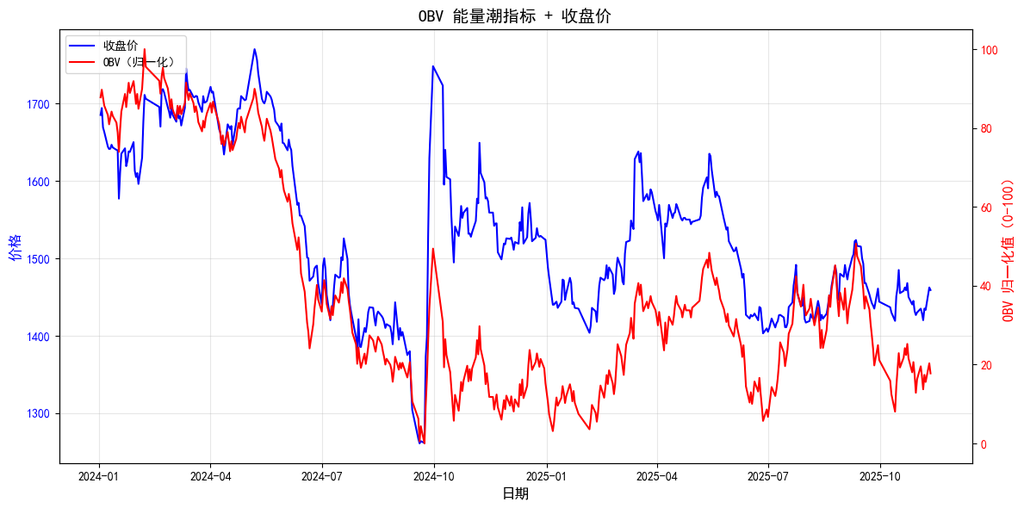

[output not shown]

```python
# 1. 计算 OBV 指标
df["OBV"] = talib.OBV(close, volume)
# 归一化 OBV（0-100），方便和股价对比
df["OBV_Norm"] = (df["OBV"] - df["OBV"].min()) / (df["OBV"].max() - df["OBV"].min()) * 100
# 收盘价归一化（0-100），同步刻度
df["Close_Norm"] = (df["Close"] - df["Close"].min()) / (df["Close"].max() - df["Close"].min()) * 100

# 去除 NaN
obv_df = df[["Close", "Close_Norm", "OBV", "OBV_Norm"]].dropna()

# 2. 单独画图（双Y轴：股价+OBV）
fig, ax1 = plt.subplots(figsize=(12, 6))

# 左Y轴：原始收盘价
ax1.plot(obv_df.index, obv_df["Close"], color="blue", linewidth=1.5, label="收盘价")
ax1.set_xlabel("日期", fontsize=12)
ax1.set_ylabel("价格", fontsize=12, color="blue")
ax1.tick_params(axis="y", labelcolor="blue")
ax1.grid(True, alpha=0.3)

# 右Y轴：归一化 OBV
ax2 = ax1.twinx()
ax2.plot(obv_df.index, obv_df["OBV_Norm"], color="red", linewidth=1.5, label="OBV（归一化）")
ax2.set_ylabel("OBV 归一化值（0-100）", fontsize=12, color="red")
ax2.tick_params(axis="y", labelcolor="red")

# 合并图例
lines1, labels1 = ax1.get_legend_handles_labels()
lines2, labels2 = ax2.get_legend_handles_labels()
ax1.legend(lines1 + lines2, labels1 + labels2, loc="upper left")

plt.title("OBV 能量潮指标 + 收盘价", fontsize=14)
plt.tight_layout()
plt.show()

# 输出量价配合信号
obv_df["量价信号"] = obv_df.apply(
    lambda x: "量价齐升（强势）" if (x["Close"] > obv_df["Close"].shift(1).iloc[obv_df.index.get_loc(x.name)-1] and
                                  x["OBV"] > obv_df["OBV"].shift(1).iloc[obv_df.index.get_loc(x.name)-1])
    else ("量价背离（警惕回调）" if (x["Close"] > obv_df["Close"].shift(1).iloc[obv_df.index.get_loc(x.name)-1] and
                                  x["OBV"] < obv_df["OBV"].shift(1).iloc[obv_df.index.get_loc(x.name)-1])
    else "正常波动"), axis=1
)
print("OBV 最新5个交易日信号：")
print(obv_df[["Close", "OBV", "量价信号"]].tail())
```

### 3. W&R（威廉指标，又称威廉超买超卖指标）

W&R（Williams &R，威廉指标）是一个通常用于判断市场是否超买或超卖的动量指标。它的计算公式如下：

### **Williams R（W&R）公式**：

$$ WR = \frac{H_n - C_t}{H_n - L_n} \times (-100) $$

其中：

- $H_n$：过去 $n$ 日的最高价。
- $L_n$：过去 $n$ 日的最低价。
- $C_t$：当前时段的收盘价。

### **计算步骤**：

1. **选择时间周期**：通常选择 14 天作为时间周期（即 n = 14），但也可以根据需要调整。
2. **计算过去 n 日的最高价 $H_n$ 和最低价 $L_n$**。
3. **计算当前收盘价 $C_t$**。
4. **代入公式进行计算**。
- W&R值范围在 -100 到 0 之间。

核心用途

- 当 W&R 接近 -100 时，表示市场超卖（价格过低，可能是买入信号）。
- 当 W&R 接近 0 时，表示市场超买（价格过高，可能是卖出信号）。
- 识别超买超卖：W&R > -20 → 超买（股价过高，可能回调）；W&R < -80 → 超卖（股价过低，可能反弹）；
- 实战场景：震荡市中，W&R 超买时卖出、超卖时买入；趋势市中需结合趋势（如多头趋势中，超卖可能是短期回调，不宜做空）。

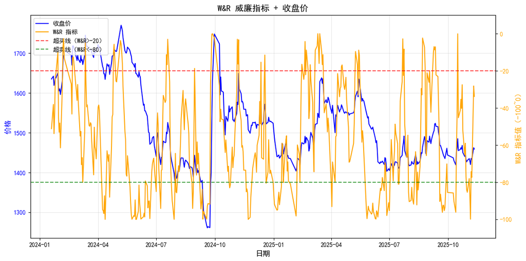

```
W&R 最新5个交易日信号：
              Close        W&R        信号
trade_date
2025-11-05  1420.08 -99.897044  超卖（可能反弹）
2025-11-06  1435.13 -74.316290      正常区间
2025-11-07  1433.33 -77.373875      正常区间
2025-11-10  1462.30 -28.163751      正常区间
2025-11-11  1458.99 -33.786309      正常区间
```

```python
# 1. 计算 W&R 指标
df["W&R"] = talib.WILLR(high, low, close, timeperiod=14)

# 去除 NaN
wr_df = df[["Close", "W&R"]].dropna()

# 2. 单独画图（双Y轴：股价+W&R）
fig, ax1 = plt.subplots(figsize=(12, 6))

# 左Y轴：收盘价
ax1.plot(wr_df.index, wr_df["Close"], color="blue", linewidth=1.5, label="收盘价")
ax1.set_xlabel("日期", fontsize=12)
ax1.set_ylabel("价格", fontsize=12, color="blue")
ax1.tick_params(axis="y", labelcolor="blue")
ax1.grid(True, alpha=0.3)

# 右Y轴：W&R（范围-100~0）
ax2 = ax1.twinx()
ax2.plot(wr_df.index, wr_df["W&R"], color="orange", linewidth=1.5, label="W&R 指标")
ax2.axhline(y=-20, color="red", linestyle="--", alpha=0.7, label="超买线（W&R>-20）")
ax2.axhline(y=-80, color="green", linestyle="--", alpha=0.7, label="超卖线（W&R<-80）")
ax2.set_ylabel("W&R 指标值（-100~0）", fontsize=12, color="orange")
ax2.tick_params(axis="y", labelcolor="orange")
ax2.set_ylim(-110, 10)  # 固定范围，更直观

# 合并图例
lines1, labels1 = ax1.get_legend_handles_labels()
lines2, labels2 = ax2.get_legend_handles_labels()
ax1.legend(lines1 + lines2, labels1 + labels2, loc="upper left")

plt.title("W&R 威廉指标 + 收盘价", fontsize=14)
plt.tight_layout()
plt.show()

# 输出超买超卖信号
wr_df["信号"] = wr_df["W&R"].apply(
    lambda x: "超买（警惕回调）" if x > -20
    else ("超卖（可能反弹）" if x < -80
    else "正常区间")
)
print("W&R 最新5个交易日信号：")
print(wr_df[["Close", "W&R", "信号"]].tail())
```

### 4. BOLL（布林带指标）

BOLL（Bollinger Bands，布林带）是一种由John Bollinger提出的技术分析工具，用于衡量价格波动性并识别超买或超卖区域。布林带由三条线组成：中轨、上轨和下轨。其计算公式如下：

### **Bollinger Bands（BOLL）公式**：

1. **中轨（MA）**： 中轨是价格的 n 日简单移动平均（SMA）：

   $$MA_n = \frac{\sum_{i=1}^{n} C_i}{n}$$

   其中，$C_i$ 是过去 n 日的收盘价。
2. **上轨（Upper Band）**：

   $$Upper\ Band = MA_n + (k \times \sigma_n) $$ 其中，k 是标准的偏移值（通常取 2）， $\sigma_n$ 是过去 n 日的标准差。
3. **下轨（Lower Band）**：

   $$Lower\ Band = MA_n - (k \times \sigma_n)$$

其中：

- $MA_n$ 是 n 日的简单移动平均（通常取 20 日）。
- $\sigma_n$ 是过去 n 日的标准差，衡量价格波动的大小。

### **标准差$\sigma_n$ 计算公式**：

$$\sigma_n = \sqrt{\frac{\sum_{i=1}^{n} (C_i - MA_n)^2}{n}}$$

其中， $C_i$ 是每一天的收盘价， $MA_n$ 是 n 日的移动平均。

### **解读**：

- **布林带的宽度**：布林带的宽度反映了市场的波动性。当价格波动增大时，上轨和下轨之间的距离会增大，反之则会缩小。
- **价格位置**：
  - 当价格接近上轨时，表示市场可能超买，可能出现回调。
  - 当价格接近下轨时，表示市场可能超卖，可能出现反弹。
  - 当价格在中轨附近波动时，表示市场处于中性状态。

### **常用的布林带策略**：

1. **价格突破布林带**：价格突破上轨或下轨时，可能预示着趋势的延续或反转。
2. **带宽收窄（Squeeze）**：当布林带收窄时，通常预示着市场波动性将增加，可能会有剧烈的价格变动。

核心用途

- 判断股价波动范围：股价在布林带内运行 → 正常波动；突破上轨 → 强势上涨（或超买）；跌破下轨 → 强势下跌（或超卖）；
- 判断趋势：布林带向上开口 → 多头趋势；向下开口 → 空头趋势；横向收缩 → 震荡市（后续可能突破）；
- 实战场景：股价突破上轨且布林带开口 → 顺势做多；股价回踩中轨不破 → 加仓机会。

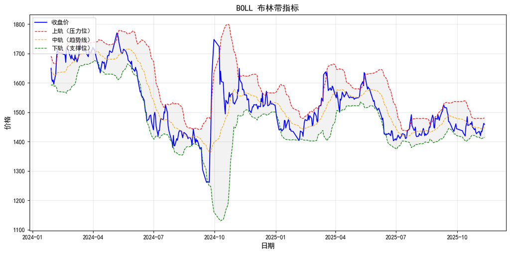

```
BOLL 最新5个交易日信号：
              Close   BOLL_Upper   BOLL_Mid   BOLL_Lower    信号
trade_date
2025-11-05  1420.08  1479.070653  1444.6960  1410.321347  区间震荡
2025-11-06  1435.13  1479.071570  1444.6135  1410.155430  区间震荡
2025-11-07  1433.33  1478.985267  1444.7800  1410.574733  区间震荡
2025-11-10  1462.30  1479.827962  1446.9350  1414.042038  区间震荡
2025-11-11  1458.99  1480.605695  1447.3335  1414.061305  区间震荡
```

```python
# 1. 计算 BOLL 指标
df["BOLL_Upper"], df["BOLL_Mid"], df["BOLL_Lower"] = talib.BBANDS(
    close, timeperiod=20, nbdevup=2, nbdevdn=2, matype=0
)

# 去除 NaN，关键：确保索引是 datetime 类型
boll_df = df[["Close", "BOLL_Upper", "BOLL_Mid", "BOLL_Lower"]].dropna().copy()
# 强制转换索引为 datetime（避免索引类型异常）
boll_df.index = pd.to_datetime(boll_df.index)

# 输出布林带信号
# 简化信号计算（不用 apply，直接用向量判断，避免索引问题）
boll_df["信号"] = "区间震荡"  # 默认值
boll_df.loc[boll_df["Close"] > boll_df["BOLL_Upper"], "信号"] = "突破上轨（强势）"
boll_df.loc[boll_df["Close"] < boll_df["BOLL_Lower"], "信号"] = "跌破下轨（弱势）"

# 3. 单独画图（价格+布林带三轨）
plt.figure(figsize=(12, 6))
plt.plot(boll_df.index, boll_df["Close"], color="blue", linewidth=1.5, label="收盘价")
plt.plot(boll_df.index, boll_df["BOLL_Upper"], color="red", linestyle="--", linewidth=1, label="上轨（压力位）")
plt.plot(boll_df.index, boll_df["BOLL_Mid"], color="orange", linestyle="--", linewidth=1, label="中轨（趋势线）")
plt.plot(boll_df.index, boll_df["BOLL_Lower"], color="green", linestyle="--", linewidth=1, label="下轨（支撑位）")

# 填充布林带区间（增强视觉效果）
plt.fill_between(boll_df.index, boll_df["BOLL_Upper"], boll_df["BOLL_Lower"], color="gray", alpha=0.1)

plt.title("BOLL 布林带指标", fontsize=14)
plt.xlabel("日期", fontsize=12)
plt.ylabel("价格", fontsize=12)
plt.legend(loc="upper left")
plt.grid(True, alpha=0.3)
plt.tight_layout()
plt.show()

# 输出 BOLL 最新信号（确保索引正常）
print("BOLL 最新5个交易日信号：")
print(boll_df[["Close", "BOLL_Upper", "BOLL_Mid", "BOLL_Lower", "信号"]].tail())
```

### 5. SAR（抛物转向指标，又称停损点转向指标）

SAR（Parabolic SAR，抛物线转向指标）是由J. Welles Wilder提出的技术分析工具，用于确定价格趋势的转折点。它可以帮助判断趋势的方向以及趋势的反转点。

### **SAR公式**：

1. **初始化**：

   初始SAR值 $SAR_0$ 等于前一时段的最低价（若处于上升趋势）或最高价（若处于下降趋势），即：

   $$SAR_t = SAR_{t-1} + AF \times (EP - SAR_{t-1})$$

   其中：
   - $SAR_{t-1}$ ：前一周期的SAR值。
   - $AF$ ：加速因子（Acceleration Factor），通常为 0.02，并且每次趋势持续时会加 0.02，最大值为 0.20。
   - $EP$ ：极值点（Extreme Point），上升趋势时为当前周期的最高价，下降趋势时为当前周期的最低价。
3. **加速因子（AF）**：
   - 在每个新周期开始时，若趋势没有发生反转，加速因子会增加 0.02，最大值为 0.20。
   - 如果趋势发生反转，加速因子将重置为 0.02。
4. **趋势反转条件**：
   - **上升趋势**：若当前周期的最低价 $L_t$ 小于 SAR，则趋势转为下降趋势。
   - **下降趋势**：若当前周期的最高价 $H_t$ 高于 SAR，则趋势转为上升趋势。

### **总结**：

- 在上升趋势中，SAR的值会逐步上升，并且接近价格的最低点。
- 在下降趋势中，SAR的值会逐步下降，并且接近价格的最高点。
- SAR的转折点是通过计算每一时段的SAR值，依赖于加速因子和极值点来确定的。

核心用途

- 判断趋势反转：股价上穿 SAR → 多头信号（买入）；股价下穿 SAR → 空头信号（卖出）；
- 设置止损止盈：SAR 可作为动态止损位（如做多时，以 SAR 为止损线，跌破则卖出）；
- 实战场景：趋势明确时（如多头），SAR 持续向上，跟随持有；一旦股价跌破 SAR，立即止损离场，避免大幅亏损。

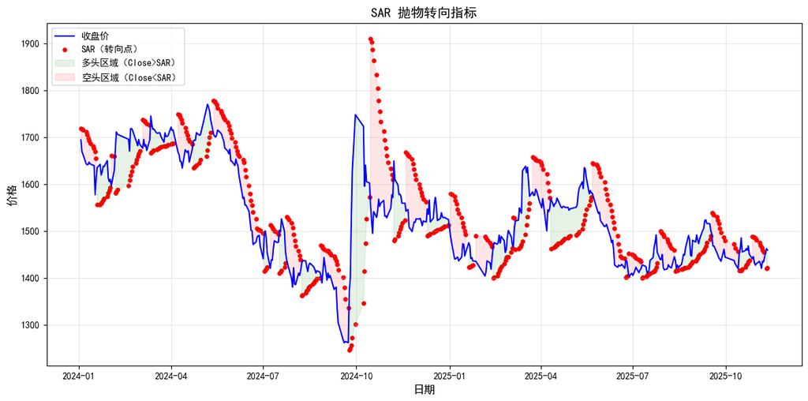

```
SAR 最新5个交易日信号：
              Close          SAR         交易信号  转向信号
trade_date
2025-11-05  1420.08  1464.731216  空头持有（卖出/空仓）  趋势延续
2025-11-06  1435.13  1459.364670  空头持有（卖出/空仓）  趋势延续
2025-11-07  1433.33  1454.642110  空头持有（卖出/空仓）  趋势延续
2025-11-10  1462.30  1420.010000  多头持有（买入/持仓）  趋势反转
2025-11-11  1458.99  1420.883600  多头持有（买入/持仓）  趋势延续
```

```python
# 1. 计算 SAR 指标
df["SAR"] = talib.SAR(high, low, acceleration=0.02, maximum=0.2)

# 去除 NaN
sar_df = df[["Close", "SAR"]].dropna()

# 2. 单独画图（价格+SAR点）
plt.figure(figsize=(12, 6))
# 收盘价线
plt.plot(sar_df.index, sar_df["Close"], color="blue", linewidth=1.5, label="收盘价")
# SAR 转向点（用散点图更清晰）
plt.scatter(sar_df.index, sar_df["SAR"], color="red", s=15, label="SAR（转向点）")

# 填充多空区域（收盘价>SAR=多头，反之空头）
plt.fill_between(
    sar_df.index,
    sar_df["Close"],
    sar_df["SAR"],
    where=(sar_df["Close"] > sar_df["SAR"]),
    color="green",
    alpha=0.1,
    label="多头区域（Close>SAR）"
)
plt.fill_between(
    sar_df.index,
    sar_df["Close"],
    sar_df["SAR"],
    where=(sar_df["Close"] < sar_df["SAR"]),
    color="red",
    alpha=0.1,
    label="空头区域（Close<SAR）"
)

plt.title("SAR 抛物转向指标", fontsize=14)
plt.xlabel("日期", fontsize=12)
plt.ylabel("价格", fontsize=12)
plt.legend(loc="upper left")
plt.grid(True, alpha=0.3)
plt.tight_layout()
plt.show()

# 输出 SAR 交易信号
sar_df["交易信号"] = sar_df.apply(
    lambda x: "多头持有（买入/持仓）" if x["Close"] > x["SAR"]
    else "空头持有（卖出/空仓）", axis=1
)
# 识别转向信号（前后周期对比）
# sar_df["转向信号"] = sar_df["交易信号"] != sar_df["交易信号"].shift(1)
# sar_df.loc[sar_df["转向信号"] == True, "转向信号"] = "趋势反转"
# sar_df.loc[sar_df["转向信号"] == False, "转向信号"] = "趋势延续"

# 先计算转向信号（bool），再直接映射为字符串
sar_df["转向信号"] = (sar_df["交易信号"] != sar_df["交易信号"].shift(1)).map(
    {True: "趋势反转", False: "趋势延续"}
)


print("SAR 最新5个交易日信号：")
print(sar_df[["Close", "SAR", "交易信号", "转向信号"]].tail())
```

总结如下：

[output not shown]

趋势市：DMI（判断趋势）+ BOLL（找入场点）+ SAR（止损）；

震荡市：W&R（超买超卖）+ BOLL（区间边界）；

量能验证：OBV 配合股价（量价齐升 / 背离，确认信号有效性）。

```
数据获取并排序成功：
数据行数：449
日期范围：2024-01-02 00:00:00 ~ 2025-11-11 00:00:00
前5行数据（排序后从最早日期开始）：
               Open     High      Low    Close    Volume
trade_date
2024-01-02  1715.00  1718.19  1678.10  1685.01  32156.44
2024-01-03  1681.11  1695.22  1676.33  1694.00  20229.29
2024-01-04  1693.00  1693.00  1662.93  1669.00  21551.07
2024-01-05  1661.33  1678.66  1652.11  1663.36  20242.86
2024-01-08  1661.00  1662.00  1640.01  1643.99  25586.20

指标计算完成，有效数据行数： 409
计算结果前5行：
              Close        +DI        -DI        ADX       ADXR       OBV  \
trade_date
2024-03-06  1680.55  20.261321  18.119220  18.852243  29.129591 -12326.18
2024-03-07  1683.63  19.641075  17.569738  17.903261  27.869670   9272.94

                  W&R   BOLL_Upper  BOLL_Mid   BOLL_Lower          SAR
trade_date
2024-03-06 -70.517390  1750.596203  1677.377  1604.157797  1733.776704
2024-03-07 -66.732211  1746.555702  1681.313  1616.070298  1731.092836
```

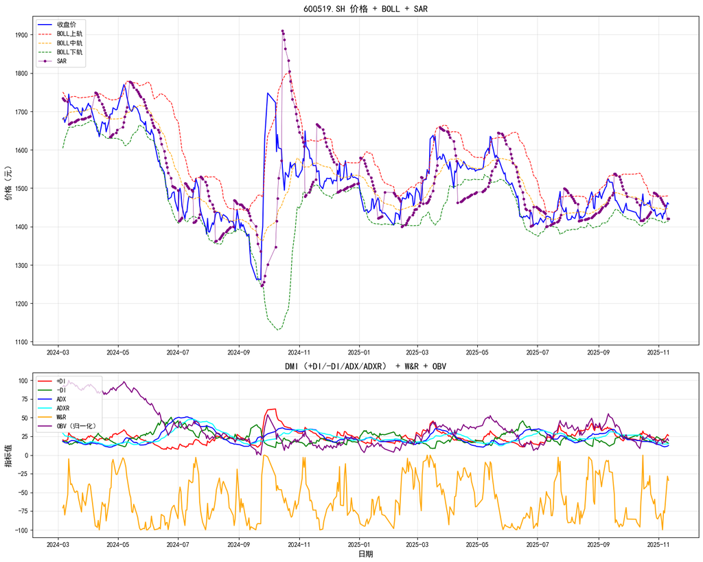

```
=== 关键指标信号解读 ===
最新10个交易日的指标信号：
              Close DMI_Trend W&R_Signal SAR_Signal
trade_date
2025-10-29  1431.90     无明显趋势       None       空头持有
2025-10-30  1426.74     无明显趋势         超卖       空头持有
2025-10-31  1430.01     无明显趋势         超卖       空头持有
2025-11-03  1435.00     无明显趋势       None       空头持有
2025-11-04  1429.00     无明显趋势         超卖       空头持有
2025-11-05  1420.08     无明显趋势         超卖       空头持有
2025-11-06  1435.13     无明显趋势       None       空头持有
2025-11-07  1433.33     无明显趋势       None       空头持有
2025-11-10  1462.30     无明显趋势       None       多头持有
2025-11-11  1458.99     无明显趋势       None       多头持有
```

```python
import os
# os.environ["YFINANCE_DISABLE_KEYRING"] = "1"  # 禁用keyring，解决yfinance报错
# proxy = 'http://127.0.0.1:7897' # 挂梯子代理设置，否则不能用yf
# os.environ['HTTP_PROXY'] = proxy
# os.environ['HTTPS_PROXY'] = proxy
# import yfinance as yf
import talib
import pandas as pd
import matplotlib.pyplot as plt
import tushare as ts
import numpy as np

# ---------------------- 1. 获取行情数据 + 严格数据校验 ----------------------
stock_code = "600519.SH"  # 贵州茅台（A股）
start_date = "20240101"  # Tushare 日期格式要求：YYYYMMDD（无横杠）
# end_date 可选：如果要指定结束日期，格式同上，例如 end_date="20251110"
ts.set_token('7c0a9136f16b24498a63ba46c9cd534bc9428f6d4c9d1f711294c911')
pro = ts.pro_api()

# 获取数据（如果要加结束日期，添加 end_date=end_date 参数）
df = pro.daily(ts_code=stock_code, start_date=start_date)

# ---------------------- 核心：df 排序步骤 ----------------------
# 1. 将 trade_date（字符串格式 YYYYMMDD）转为 datetime 类型（便于正确排序）
df["trade_date"] = pd.to_datetime(df["trade_date"])

# 2. 按 trade_date 升序排序（ oldest → newest，时间从早到晚）
# ascending=True：升序（默认）；ascending=False：降序（时间从晚到早）
df = df.sort_values(by="trade_date", ascending=True)

# 3. （可选但推荐）将 trade_date 设为索引，后续指标计算更方便
df = df.set_index("trade_date")

# ---------------------- 后续数据处理（保持之前的逻辑）----------------------
# 重命名列名，适配后续指标计算（Tushare 列名为小写，统一为大写）
df.rename(columns={
    "open": "Open",
    "high": "High",
    "low": "Low",
    "close": "Close",
    "vol": "Volume"  # Tushare 成交量列名是 vol，对应之前的 Volume
}, inplace=True)

# 保留核心列
df = df[["Open", "High", "Low", "Close", "Volume"]].copy()

# 数据清洗：强制数值类型+去异常值
for col in df.columns:
    df[col] = pd.to_numeric(df[col], errors="coerce")
df = df.dropna()  # 去除 NaN 行
df = df.drop_duplicates()  # 去除重复行
df = df.replace([np.inf, -np.inf], np.nan).dropna()  # 去除无穷大值

# 长度校验（至少 28 行，满足 14 期 DMI 计算）
min_data_len = 28
if len(df) < min_data_len:
    raise ValueError(f"数据长度不足！至少需要 {min_data_len} 行，当前仅 {len(df)} 行")

print("数据获取并排序成功：")
print(f"数据行数：{len(df)}")
print(f"日期范围：{df.index.min()} ~ {df.index.max()}")  # 排序后索引是 datetime 类型，直接显示日期
print("前5行数据（排序后从最早日期开始）：")
print(df.head())


# ---------------------- 2. 指标计算（核心修复：DMI函数调用）----------------------
high = df["High"].values.ravel().astype(np.float64)
low = df["Low"].values.ravel().astype(np.float64)
close = df["Close"].values.ravel().astype(np.float64)
volume = df["Volume"].values.ravel().astype(np.float64)

# 2.1 DMI（动向指标）：
df["+DI"] = talib.PLUS_DI(high, low, close, timeperiod=14)  # 单独计算+DI
df["-DI"] = talib.MINUS_DI(high, low, close, timeperiod=14)  # 单独计算-DI
df["ADX"] = talib.ADX(high, low, close, timeperiod=14)      # 单独计算ADX
df["ADXR"] = talib.ADXR(high, low, close, timeperiod=14)    # 单独计算ADXR

# 2.2 OBV（能量潮）
df["OBV"] = talib.OBV(close, volume)

# 2.3 W&R（威廉指标）
df["W&R"] = talib.WILLR(high, low, close, timeperiod=14)

# 2.4 BOLL（布林带）
df["BOLL_Upper"], df["BOLL_Mid"], df["BOLL_Lower"] = talib.BBANDS(
    close, timeperiod=20, nbdevup=2, nbdevdn=2, matype=0
)

# 2.5 SAR（抛物转向指标）
df["SAR"] = talib.SAR(high, low, acceleration=0.02, maximum=0.2)

# 去除指标计算产生的初始NaN（滚动计算需要N期数据）
df = df.dropna()
print("\n指标计算完成，有效数据行数：", len(df))
print("计算结果前5行：")
print(df[["Close", "+DI", "-DI", "ADX", "ADXR", "OBV", "W&R", "BOLL_Upper", "BOLL_Mid", "BOLL_Lower", "SAR"]].head(2))

# ---------------------- 3. 可视化（不变）----------------------
plt.rcParams["font.sans-serif"] = ["SimHei"]
plt.rcParams["axes.unicode_minus"] = False
fig, (ax1, ax2) = plt.subplots(2, 1, figsize=(15, 12), gridspec_kw={"height_ratios": [2, 1]})

# 子图1：价格 + BOLL + SAR
ax1.plot(df.index, df["Close"], label="收盘价", color="blue", linewidth=1.5)
ax1.plot(df.index, df["BOLL_Upper"], label="BOLL上轨", color="red", linestyle="--", linewidth=1)
ax1.plot(df.index, df["BOLL_Mid"], label="BOLL中轨", color="orange", linestyle="--", linewidth=1)
ax1.plot(df.index, df["BOLL_Lower"], label="BOLL下轨", color="green", linestyle="--", linewidth=1)
ax1.plot(df.index, df["SAR"], label="SAR", color="purple", marker="o", markersize=3, linewidth=0.5)
ax1.set_title(f"{stock_code} 价格 + BOLL + SAR", fontsize=14)
ax1.set_ylabel("价格（元）", fontsize=12)
ax1.legend(loc="upper left")
ax1.grid(True, alpha=0.3)

# 子图2：DMI + W&R + OBV（归一化）
df["OBV_Norm"] = (df["OBV"] - df["OBV"].min()) / (df["OBV"].max() - df["OBV"].min()) * 100
ax2.plot(df.index, df["+DI"], label="+DI", color="red", linewidth=1.5)
ax2.plot(df.index, df["-DI"], label="-DI", color="green", linewidth=1.5)
ax2.plot(df.index, df["ADX"], label="ADX", color="blue", linewidth=1.5)
ax2.plot(df.index, df["ADXR"], label="ADXR", color="cyan", linewidth=1.5)
ax2.plot(df.index, df["W&R"], label="W&R", color="orange", linewidth=1.5)
ax2.plot(df.index, df["OBV_Norm"], label="OBV（归一化）", color="purple", linewidth=1.5)
ax2.set_title("DMI（+DI/-DI/ADX/ADXR） + W&R + OBV", fontsize=14)
ax2.set_ylabel("指标值", fontsize=12)
ax2.set_xlabel("日期", fontsize=12)
ax2.legend(loc="upper left")
ax2.grid(True, alpha=0.3)
ax2.set_ylim(-110, 110)

plt.tight_layout()
plt.show()

# ---------------------- 4. 指标信号解读（不变）----------------------
print("\n=== 关键指标信号解读 ===")
df["DMI_Trend"] = None
df.loc[(df["ADX"] > 25) & (df["+DI"] > df["-DI"]), "DMI_Trend"] = "多头趋势"
df.loc[(df["ADX"] > 25) & (df["+DI"] < df["-DI"]), "DMI_Trend"] = "空头趋势"
df.loc[df["ADX"] < 20, "DMI_Trend"] = "无明显趋势"

df["W&R_Signal"] = None
df.loc[df["W&R"] < -80, "W&R_Signal"] = "超卖"
df.loc[df["W&R"] > -20, "W&R_Signal"] = "超买"

df["SAR_Signal"] = None
df.loc[df["Close"] > df["SAR"], "SAR_Signal"] = "多头持有"
df.loc[df["Close"] < df["SAR"], "SAR_Signal"] = "空头持有"

print("最新10个交易日的指标信号：")
print(df[["Close", "DMI_Trend", "W&R_Signal", "SAR_Signal"]].tail(10).to_string())
```